# Week 6

# Submitter - Himanshu Singh

# Fraud Waste Abuse Detection in Healthcare Insurance - Project Milestone 1

# Data Selection and EDA

## Problem Statement

The primary objective of this project is to develop a predictive model to identify Fraud, Waste, and Abuse (FWA) among healthcare providers. By analyzing claims data, the project aims to "Predict potentially fraudulent providers" while uncovering the most significant variables that signal suspicious behavior. This intelligence allows organizations to flag high-risk claims for in-depth investigation, ensuring that resources are directed toward the most likely instances of financial leakage.

## Problem Description

Healthcare insurance is a vital pillar of social stability, protecting citizens from the financial hardships of medical uncertainty. However, the integrity of both public and private insurance schemes is constantly threatened by Fraud, Waste, and Abuse (FWA):

Fraud: Intentional deception or misrepresentation, such as billing for services never rendered or "phantom" patients. Waste: Overutilization of services or practices that result in unnecessary costs, such as performing excessive diagnostic tests that are not medically required. Abuse: Actions that are inconsistent with sound fiscal, business, or medical practices, resulting in improper payment (e.g., upcoding or unbundling procedures).

FWA is often an organized crime involving collusion between providers, physicians, and beneficiaries. Specifically, Provider Fraud is a massive burden on Medicare; for instance, providers may exaggerate billing amounts or facilitate benefits for unauthorized individuals.

The cost of misidentification is high: failing to detect FWA leads to substantial financial losses, while incorrectly flagging legitimate providers (False Positives) causes administrative friction and delays essential patient care. A precise, data-driven approach is required to balance aggressive cost recovery with the smooth adjudication of valid claims.

### Real-Life Examples in FWA Detection

Fraud (Intentional Deception): A provider submits claims for a series of complex MRIs for patients who, according to demographic data, live 500 miles away and never visited the clinic. Data Mining Perspective: We can look for geospatial anomalies and a lack of corresponding primary care referrals.

Waste (Unnecessary Costs): A clinic consistently orders expensive "comprehensive metabolic panels" for every single patient visit, regardless of the diagnosis (e.g., even for a simple flu shot). Data Mining Perspective: This is identified through frequency analysis and comparing a provider's behavior against the "peer group" average for the same specialty.

Abuse (Improper Practice): A surgeon performs a single operation but bills for three separate "sub-procedures" to increase the payout (known as unbundling). Data Mining Perspective: We can use Association Rule Mining to find procedure codes that should logically be billed under a single global fee but are appearing as separate line items.

Source of data: Elsevier''s Mendeley Data repository is a participating member of the National Institutes of Health (NIH) Office of Data Science Strategy (ODSS) GREI project. liang, tim (2024), “HEALTHCARE PROVIDER FRAUD DETECTION ANALYSIS”, Mendeley Data, V1, doi: 10.17632/gsn2hyty37.1 https://data.mendeley.com/datasets/gsn2hyty37/1

```python
import pandas as pd
import os
import numpy as np
import matplotlib.pyplot as plt
import numpy as np
import seaborn as sns
import warnings
warnings.filterwarnings('ignore')
from tqdm import tqdm
```

```python
data = pd.read_csv('Train.csv')
data_beneficiary = pd.read_csv('Train_Beneficiarydata.csv')
data_inpatient = pd.read_csv('Train_Inpatientdata.csv')
data_outpatient = pd.read_csv('Train_Outpatientdata.csv')

print("data : ",data.shape)
print("beneficiary_data : ",data_beneficiary.shape)
print("inpatient_data : ",data_inpatient.shape)
print("outpatient_data : ",data_outpatient.shape)
```

```
data :  (5410, 2)
beneficiary_data :  (138556, 25)
inpatient_data :  (40474, 30)
outpatient_data :  (517737, 27)
```

# Exploratory Data Analysis

# 1 . Procedure Code and Diagnosis Codes Analysis

## Inpatient Records Data Analysis

### Inpatient Data - Inpatient Data refers to records for patients who have been formally admitted to a hospital or medical facility for at least one night.

```python
#Getting all the columns of Inpatient data
print('Columns in this dataset are : ')
print(data_inpatient.columns)

data_inpatient.head(5)
```

```
Columns in this dataset are :
Index(['BeneID', 'ClaimID', 'ClaimStartDt', 'ClaimEndDt', 'Provider',
       'InscClaimAmtReimbursed', 'AttendingPhysician', 'OperatingPhysician',
       'OtherPhysician', 'AdmissionDt', 'ClmAdmitDiagnosisCode',
       'DeductibleAmtPaid', 'DischargeDt', 'DiagnosisGroupCode',
       'ClmDiagnosisCode_1', 'ClmDiagnosisCode_2', 'ClmDiagnosisCode_3',
       'ClmDiagnosisCode_4', 'ClmDiagnosisCode_5', 'ClmDiagnosisCode_6',
       'ClmDiagnosisCode_7', 'ClmDiagnosisCode_8', 'ClmDiagnosisCode_9',
       'ClmDiagnosisCode_10', 'ClmProcedureCode_1', 'ClmProcedureCode_2',
       'ClmProcedureCode_3', 'ClmProcedureCode_4', 'ClmProcedureCode_5',
       'ClmProcedureCode_6'],
      dtype='object')
```

|  | BeneID | ClaimID | ClaimStartDt | ClaimEndDt | Provider | InscClaimAmtReimbursed | AttendingPhysician | OperatingPhysician | OtherPhysician | AdmissionDt | ... | ClmDiagnosisCode_7 | ClmDiagnosisCode_8 | ClmDiagnosisCode_9 | ClmDiagnosisCode_10 | ClmProcedureCode_1 | ClmProcedureCode_2 | ClmProcedureCode_3 | ClmProcedureCode_4 | ClmProcedureCode_5 | ClmProcedureCode_6 |
| --- | --- | --- | --- | --- | --- | --- | --- | --- | --- | --- | --- | --- | --- | --- | --- | --- | --- | --- | --- | --- | --- |
| 0 | BENE11001 | CLM46614 | 2009-04-12 | 2009-04-18 | PRV55912 | 26000 | PHY390922 | NaN | NaN | 2009-04-12 | ... | 2724 | 19889 | 5849 | NaN | NaN | NaN | NaN | NaN | NaN | NaN |
| 1 | BENE11001 | CLM66048 | 2009-08-31 | 2009-09-02 | PRV55907 | 5000 | PHY318495 | PHY318495 | NaN | 2009-08-31 | ... | NaN | NaN | NaN | NaN | 7092.0 | NaN | NaN | NaN | NaN | NaN |
| 2 | BENE11001 | CLM68358 | 2009-09-17 | 2009-09-20 | PRV56046 | 5000 | PHY372395 | NaN | PHY324689 | 2009-09-17 | ... | NaN | NaN | NaN | NaN | NaN | NaN | NaN | NaN | NaN | NaN |
| 3 | BENE11011 | CLM38412 | 2009-02-14 | 2009-02-22 | PRV52405 | 5000 | PHY369659 | PHY392961 | PHY349768 | 2009-02-14 | ... | 25062 | 40390 | 4019 | NaN | 331.0 | NaN | NaN | NaN | NaN | NaN |
| 4 | BENE11014 | CLM63689 | 2009-08-13 | 2009-08-30 | PRV56614 | 10000 | PHY379376 | PHY398258 | NaN | 2009-08-13 | ... | 5119 | 29620 | 20300 | NaN | 3893.0 | NaN | NaN | NaN | NaN | NaN |

5 rows × 30 columns

We will try to analyze the data we have

This data contains Diagnosis Code and Procedure Codes

- Diagnosis Codes (primarily ICD-10 codes) are the standardized alphanumeric strings used to describe a patient’s medical condition, symptoms, or injuries.
- Procedure Codes are standardized numeric or alphanumeric codes used to identify the specific medical, surgical, or diagnostic services provided to a patient. While Diagnosis Codes explain "why" the patient is there, Procedure Codes explain "what" was done to them.

Since there are multiple service and procedure code associated to each claim we will combine them together and sort, so that it doesn't give us multiple sets of same procedure and services

Eg : Knee Surgery will have Anaesthesia + Arthroscopically aided ACL reconstruction, the sort and combine will give us combination of procedure.

We will try to find which Procedure and Diagnonsis are the top reported in the dataset we got.

```python
# Function to analyse categorical columns

def analyse_cat_columns(dataset, col_to_analyse, prefix='', title='Distribution in percentage',
                        top_val=30, y_lim=None, color='green'):
    """Plots a bar graph for the percentage distribution of a categorical column."""

    # Calculate counts and convert to percentage in one step
    counts = dataset[col_to_analyse].value_counts().head(top_val)
    percentages = (counts / len(dataset)) * 100

    # Create the plot labels with the optional prefix
    labels = [f"{prefix}{label}" for label in percentages.index]

    # Plotting
    plt.figure(figsize=(15, 5))
    plt.bar(labels, percentages.values, color=color)

    # Formatting
    plt.title(title)
    plt.ylabel('Percentage (%)')
    plt.xlabel(col_to_analyse)
    plt.xticks(rotation=45)
    plt.grid(axis='y', linestyle='--', alpha=0.7)

    if y_lim is not None:
        plt.yticks(y_lim)

    plt.tight_layout()
    plt.show()
```

```python
# Select all columns that start with 'ClmProcedureCode'
proc_cols = [col for col in data_inpatient.columns if 'ClmProcedureCode' in col]

# Concatenate them all and drop NaNs
inpatient_df = pd.DataFrame(
    pd.concat([data_inpatient[col] for col in proc_cols], axis=0).dropna(),
    columns=['ProcedureCode']
)

print(f"Total Procedures Found: {inpatient_df.shape[0]}")

print(inpatient_df.shape)
```

```
Total Procedures Found: 29692
(29692, 1)
```

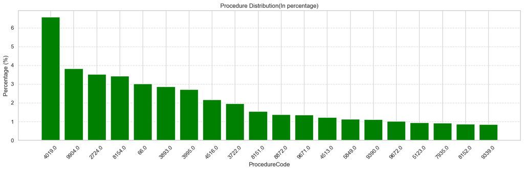

```python
analyse_cat_columns(inpatient_df,col_to_analyse='ProcedureCode' ,title = 'Procedure Distribution(In percentage)',top_val = 20)
```

# Conclusion

#### 4019.0 (Other biopsy of lymphatic structures) is the most used procedure code in the dataset. About 6% claims have that procedure code. Since this is the most common procedure, it should be the first target for "Peer Comparison" analysis to see if specific providers are billing it at a rate significantly higher than the 6.6% average

#### The top 5 procedures—4019, 9904 (Blood Transfusion), 2724 (Hip Replacement/Repair), 8154 (Total Knee Replacement), and 66 (CS Section/Other)—represent the core surgical and clinical volume. FWA Impact: High-cost procedures like 8154 and 2724 are high-risk areas for "Upcoding," where a simple repair might be billed as a complex total replacement.

```python
# Automatically grabs ClmDiagnosisCode_1 through ClmDiagnosisCode_10
diag_cols = data_inpatient.filter(like='ClmDiagnosisCode').columns

# Concatenate into a single Series and remove missing values
inpatient_diag_df = pd.DataFrame(
    pd.concat([data_inpatient[col] for col in diag_cols], axis=0).dropna(),
    columns=['DiagnosisCode']
)

print(f"Total Diagnosis Occurrences: {inpatient_diag_df.shape[0]}")
print(inpatient_diag_df.shape)
```

```
Total Diagnosis Occurrences: 327328
(327328, 1)
```

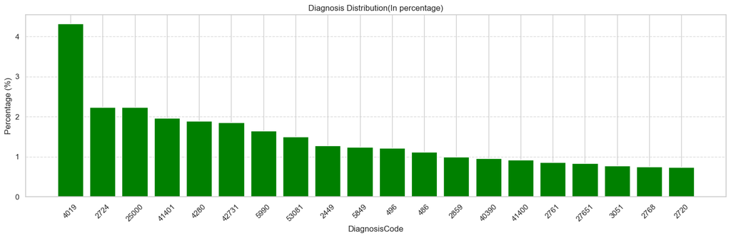

```python
analyse_cat_columns(inpatient_diag_df,col_to_analyse='DiagnosisCode' ,
                    title = 'Diagnosis Distribution(In percentage)',
                    top_val = 20, color ='green')
```

# Conclusion

#### Interestingly 4019 is the most used Diag code in the dataset which coincidently looks like the Procedure code 4019. About 4% claims have that diag code.

#### The top 5 diagnosis codes—4019 (Hypertension), 2724 (High Cholesterol), 25000 (Type 2 Diabetes), 41401 (Coronary Artery Disease), and 4280 (Congestive Heart Failure)—are all chronic conditions. FWA Insight: These are frequently used as "secondary" diagnoses to increase the complexity level of a claim, which can lead to higher reimbursement (a practice known as "Coding Creep").

# Outpatient Records Data Analysis

### Outpatient Data - In healthcare analytics, Outpatient Data refers to medical services provided to patients who are not admitted to a hospital (stays lasting less than 24 hours). This dataset is typically much larger and more "noisy" than inpatient data because it covers a vast range of routine interactions.

```python
#Getting all the columns of Outpatient data
print('Columns in this dataset are : ')
print(data_outpatient.columns)

data_outpatient.head(5)
```

```
Columns in this dataset are :
Index(['BeneID', 'ClaimID', 'ClaimStartDt', 'ClaimEndDt', 'Provider',
       'InscClaimAmtReimbursed', 'AttendingPhysician', 'OperatingPhysician',
       'OtherPhysician', 'ClmDiagnosisCode_1', 'ClmDiagnosisCode_2',
       'ClmDiagnosisCode_3', 'ClmDiagnosisCode_4', 'ClmDiagnosisCode_5',
       'ClmDiagnosisCode_6', 'ClmDiagnosisCode_7', 'ClmDiagnosisCode_8',
       'ClmDiagnosisCode_9', 'ClmDiagnosisCode_10', 'ClmProcedureCode_1',
       'ClmProcedureCode_2', 'ClmProcedureCode_3', 'ClmProcedureCode_4',
       'ClmProcedureCode_5', 'ClmProcedureCode_6', 'DeductibleAmtPaid',
       'ClmAdmitDiagnosisCode'],
      dtype='object')
```

|  | BeneID | ClaimID | ClaimStartDt | ClaimEndDt | Provider | InscClaimAmtReimbursed | AttendingPhysician | OperatingPhysician | OtherPhysician | ClmDiagnosisCode_1 | ... | ClmDiagnosisCode_9 | ClmDiagnosisCode_10 | ClmProcedureCode_1 | ClmProcedureCode_2 | ClmProcedureCode_3 | ClmProcedureCode_4 | ClmProcedureCode_5 | ClmProcedureCode_6 | DeductibleAmtPaid | ClmAdmitDiagnosisCode |
| --- | --- | --- | --- | --- | --- | --- | --- | --- | --- | --- | --- | --- | --- | --- | --- | --- | --- | --- | --- | --- | --- |
| 0 | BENE11002 | CLM624349 | 2009-10-11 | 2009-10-11 | PRV56011 | 30 | PHY326117 | NaN | NaN | 78943 | ... | NaN | NaN | NaN | NaN | NaN | NaN | NaN | NaN | 0 | 56409 |
| 1 | BENE11003 | CLM189947 | 2009-02-12 | 2009-02-12 | PRV57610 | 80 | PHY362868 | NaN | NaN | 6115 | ... | NaN | NaN | NaN | NaN | NaN | NaN | NaN | NaN | 0 | 79380 |
| 2 | BENE11003 | CLM438021 | 2009-06-27 | 2009-06-27 | PRV57595 | 10 | PHY328821 | NaN | NaN | 2723 | ... | NaN | NaN | NaN | NaN | NaN | NaN | NaN | NaN | 0 | NaN |
| 3 | BENE11004 | CLM121801 | 2009-01-06 | 2009-01-06 | PRV56011 | 40 | PHY334319 | NaN | NaN | 71988 | ... | NaN | NaN | NaN | NaN | NaN | NaN | NaN | NaN | 0 | NaN |
| 4 | BENE11004 | CLM150998 | 2009-01-22 | 2009-01-22 | PRV56011 | 200 | PHY403831 | NaN | NaN | 82382 | ... | NaN | NaN | NaN | NaN | NaN | NaN | NaN | NaN | 0 | 71947 |

5 rows × 27 columns

Same as Inpatient data, we will try to see which Diag and Procedure code are highly used in Outpatient data.

```python
# Select all columns that start with 'ClmProcedureCode'
proc_cols = [col for col in data_outpatient.columns if 'ClmProcedureCode' in col]

# Concatenate them all and drop NaNs
outpatient_df = pd.DataFrame(
    pd.concat([data_outpatient[col] for col in proc_cols], axis=0).dropna(),
    columns=['ProcedureCode']
)

print(f"Total Procedures Found: {outpatient_df.shape[0]}")

print(outpatient_df.shape)
```

```
Total Procedures Found: 204
(204, 1)
```

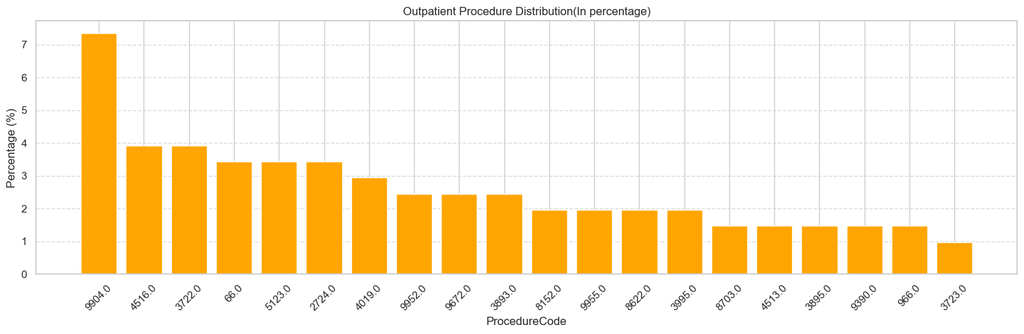

```python
analyse_cat_columns(outpatient_df,col_to_analyse='ProcedureCode' ,title = 'Outpatient Procedure Distribution(In percentage)',top_val = 20, color='orange')
```

# Conclusion

#### 9904.0 (Packed Cell Transfusion) is the most frequent outpatient procedure, appearing in 7.5% of records. FWA Insight: High volumes of transfusions in an outpatient setting are unusual and may suggest "Infusion Suite" fraud or billing for services that should require inpatient oversight.

#### The presence of 3722 (Extracorporeal circulation auxiliary to open heart surgery) and 2724 (Net or tissue graft) in the top 5 suggests outpatient data contains many high-intensity "Day Surgeries."

```python
# Automatically grabs ClmDiagnosisCode_1 through ClmDiagnosisCode_10
diag_cols = data_outpatient.filter(like='ClmDiagnosisCode').columns

# Concatenate into a single Series and remove missing values
outpatient_diag_df = pd.DataFrame(
    pd.concat([data_outpatient[col] for col in diag_cols], axis=0).dropna(),
    columns=['DiagnosisCode']
)

print(f"Total Diagnosis Occurrences: {outpatient_diag_df.shape[0]}")
print(outpatient_diag_df.shape)
```

```
Total Diagnosis Occurrences: 1353388
(1353388, 1)
```

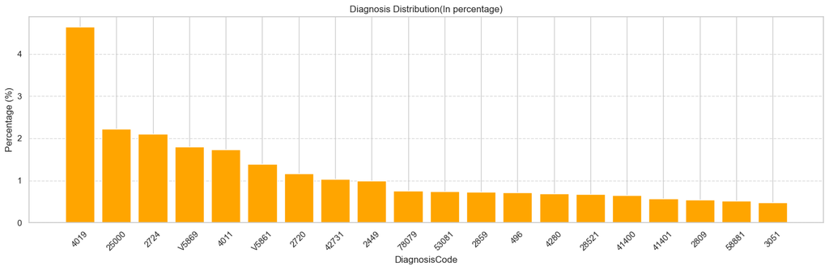

```python
analyse_cat_columns(outpatient_diag_df,col_to_analyse='DiagnosisCode' ,
                    title = 'Diagnosis Distribution(In percentage)',
                    top_val = 20, color ='orange')
```

# Conclusion

#### Diagnosis code 4019 (Unspecified Essential Hypertension) is the leading diagnosis, identified in 4.8% of all outpatient claims.

#### The top codes—4019, 25000 (Diabetes), and 2724 (High Cholesterol)—show that outpatient services are heavily utilized for managing long-term metabolic health.

#### The inclusion of V5869 (Long-term use of other medications) in the top 5 is highly significant. In outpatient data, this code is often used to justify frequent follow-up visits and lab tests. FWA Insight: Excessive use of V-codes alongside routine office visits can sometimes be a sign of "Churning," where providers schedule unnecessary appointments under the guise of "monitoring medication."

# 2 . Physician Analysis on number of claims

Why this is critical for Fraud, Waste, and Abuse (FWA) Identification of "Super-Billers": If one physician is filing significantly more claims than their peers, it could indicate "Phantom Billing" (billing for patients they never actually saw) or "Churning" (requiring unnecessary follow-up visits).

Capacity Analysis: In some fraud cases, data mining reveals that a single physician "performed" more surgeries in a 24-hour period than is humanly possible. This visualization helps spot those "impossible" volumes.

Audit Prioritization: Instead of auditing every provider, investigators use this specific list to prioritize "High-Yield" audits—focusing where the most money (and potentially the most fraud) is concentrated.

Attending Physician: The doctor who has primary responsibility for the patient's care and treatment during the entire hospital stay or clinic visit. They "own" the patient's record and oversee the overall medical plan.

Operating Physician: The specific doctor who performs a surgical or non-surgical procedure. In many outpatient cases, the Attending and Operating physician are the same person, but in complex cases, they differ.

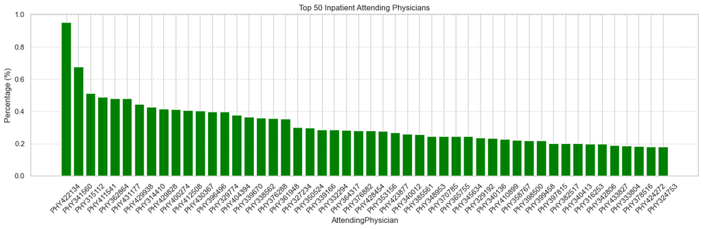

```python
# Analyse Attending Physicians in Inpatient Data

analyse_cat_columns(data_inpatient,
                    col_to_analyse='AttendingPhysician',
                    title='Top 50 Inpatient Attending Physicians',
                    top_val=50,
                    color='green')
```

# Conclusion

#### Analysis of the Attending Physician distribution reveals a high concentration of claims among the top 20 providers. In a fraud detection context, these 'Super-Billers' represent the highest financial risk. Further investigation is required to determine if their high volume is justified by their specialty or if it represents an anomaly such as excessive service utilization (Waste) or fictitious billing (Fraud).

#### Most patients are attended by physician PHY422134. Around 1% of the patients are attended by physician PHY422134

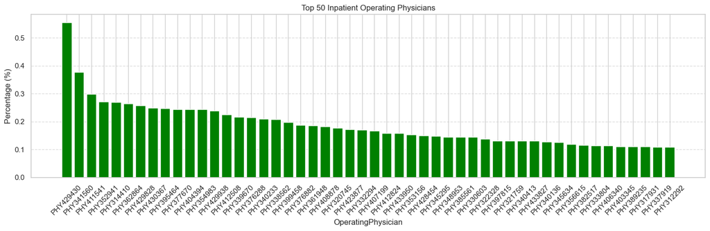

```python
# Analyse Operating Physicians in Inpatient Data

analyse_cat_columns(data_inpatient,
                    col_to_analyse='OperatingPhysician',
                    title='Top 50 Inpatient Operating Physicians',
                    top_val=50,
                    color='green')
```

# Conclusion

#### Most patients are operated by physician PHY429430. Around 0.55% of the patients are operated by physician PHY429430

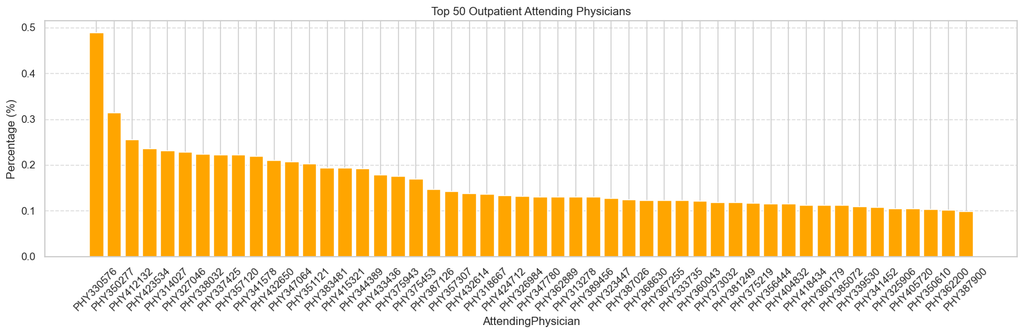

```python
# Analyse Attending Physicians in Outpatient Data

analyse_cat_columns(data_outpatient,
                    col_to_analyse='AttendingPhysician',
                    title='Top 50 Outpatient Attending Physicians',
                    top_val=50,
                    color='orange')
```

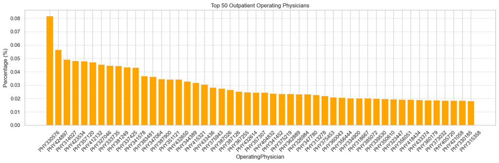

```python
# Analyse Operating  Physicians in Outpatient Data

analyse_cat_columns(data_outpatient,
                    col_to_analyse='OperatingPhysician',
                    title='Top 50 Outpatient Operating Physicians',
                    top_val=50,
                    color='orange')
```

# Conclusion

#### Most patients are operated by physician PHY330576 and attending provider is also same which a legit scenario is Outpatient claims

```python
# Analyzing the relationship between these two roles allows us to detect sophisticated fraud schemes:
# An Attending Physician consistently refers patients to the same Operating Physician for unnecessary surgeries.

# To analyze these together, we can create a "Pairing" feature in Python. This helps find "Closed Loops"
#  where two doctors are working together suspiciously often.

# Also for Outpatient claims mostly Attanding and Operating physicians are same.

# Create a unique 'Team' ID for every claim
data_outpatient['Physician_Team'] = (
    data_outpatient['AttendingPhysician'] + "_" + data_outpatient['OperatingPhysician']
)

# Find the most common teams
top_teams = data_outpatient['Physician_Team'].value_counts().head(10)
print(top_teams)
```

```
Physician_Team
PHY330576_PHY330576    406
PHY350277_PHY424897    293
PHY412132_PHY412132    227
PHY314027_PHY314027    214
PHY327046_PHY327046    186
PHY347064_PHY347064    183
PHY351121_PHY351121    179
PHY383481_PHY383481    179
PHY432650_PHY432650    174
PHY344389_PHY344389    165
Name: count, dtype: int64
```

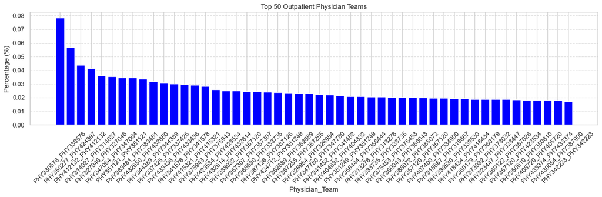

```python
analyse_cat_columns(data_outpatient,
                    col_to_analyse='Physician_Team',
                    title='Top 50 Outpatient Physician Teams',
                    top_val=50,
                    color='blue')
```

# Conclusion

#### The top combination is legit one where attending and operating physician providers are same. For others where they are different data needs to be analyzed.

# 3 . Analysis of Claim Amount Reimbursed

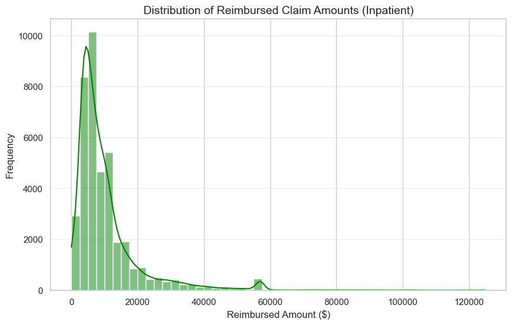

```python
# Checking distribution of Claim amount for Inpatient Claims

plt.figure(figsize=(10, 6))
# Using histplot for a more modern, detailed view
sns.histplot(data_inpatient['InscClaimAmtReimbursed'], kde=True, color='green', bins=50)

plt.title('Distribution of Reimbursed Claim Amounts (Inpatient)', fontsize=14)
plt.xlabel('Reimbursed Amount ($)', fontsize=12)
plt.ylabel('Frequency', fontsize=12)
plt.grid(axis='y', alpha=0.3)
plt.show()
```

# Conclusion

#### Right Skewness: Amount distribution is heavily "right-skewed," meaning the majority of claims are for small amounts, with a few very expensive outliers (like major surgeries).

#### Outliers: Claims that fall far to the right of the tail are the "High-Dollar" risks. These require the most scrutiny because a single fraudulent high-dollar claim can cause more damage than hundreds of small ones.

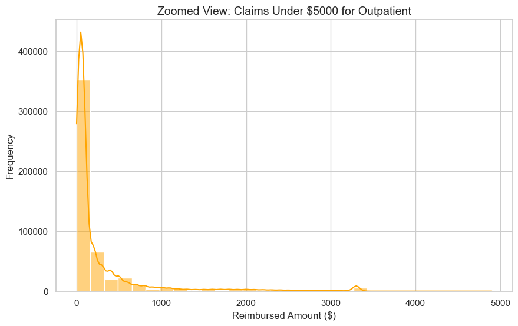

```python
# Checking distribution of Claim amount for Outpatient Claims

# Create a temporary view of only small claims
small_claims = data_outpatient[data_outpatient['InscClaimAmtReimbursed'] < 5000]

plt.figure(figsize=(10, 6))
sns.histplot(small_claims['InscClaimAmtReimbursed'], kde=True, color='orange', bins=30)

plt.title('Zoomed View: Claims Under $5000 for Outpatient', fontsize=14)
plt.xlabel('Reimbursed Amount ($)')
plt.ylabel('Frequency')
plt.show()
```

# Conclusion

#### The distribution of Outpatient Reimbursed Amounts exhibits extreme right-skewness, with the vast majority of claims falling below $1000. The presence of claims reaching up to $3000 indicates a small subset of high-cost outpatient procedures. For FWA detection, these high-dollar outliers should be cross-referenced with Provider IDs to determine if a single provider is disproportionately responsible for these expensive claims

# Here are the high-level conclusions we can derive by connecting three data points (codes, amount and Provider): (which can change in future based on further analysis)

#### Identifying "Upcoding" Patterns (Codes + Amounts) - By correlating Procedure Codes with the Reimbursed Amount, we can determine if a provider is billing for high-intensity services (like complex surgeries) when the diagnosis only supports a minor intervention.

#### Conclusion: If the average reimbursement for a specific provider is significantly higher than the peer mean for the same procedure code, it indicates potential Upcoding or the unbundling of services to inflate the claim.

#### Detection of "Impossible Volume" (Provider + Claims) - Analysis of the top-billing providers (like "Super-Biller" PHY422134) allows us to perform a capacity check.

#### Conclusion: If a provider's claim count exceeds the 99th percentile of their peer group, they are a high-risk outlier. If the number of procedures billed in a 24-hour window exceeds human capacity, we have a strong indicator of Phantom Billing (billing for services never rendered).

#### Specialization Anomaly (Codes + Provider) - By looking at which codes a specific provider uses most, we can spot "out-of-specialty" billing.

#### Conclusion: If a General Practitioner (Attending Physician) is consistently appearing as the Operating Physician for highly specialized codes (like 3722 - Heart Surgery), it flags a major Credentialing Fraud or Scope of Practice violation.

## We will not try to go in details of service codes, procedure code and specialty related to Provider. Our focus will be based on the dataset we have. But this also can be check to reduce FWA in Healthcare industry.

# Term Project Milestone 2: Data Preparation

Here is a list of steps to consider performing in Milestone 2:

- Drop any features that are not useful for your model building and explain why they are not useful.
- Perform any data extraction/selection steps.
- Transform features if necessary.
- Engineer new useful features.
- Deal with missing data (do not just drop rows or columns without justifying this).
- Create dummy variables if necessary.

We need to complete some more EDA for the project

# 4 . Analysis of Labeled data

```python
#check all the columns of the labeled  dataset and top 5 data points
print('Columns in this dataset are : ')
print(data.columns)

data.head(5)
```

```
Columns in this dataset are :
Index(['Provider', 'PotentialFraud'], dtype='object')
```

|  | Provider | PotentialFraud |
| --- | --- | --- |
| 0 | PRV51001 | No |
| 1 | PRV51003 | Yes |
| 2 | PRV51004 | No |
| 3 | PRV51005 | Yes |
| 4 | PRV51007 | No |

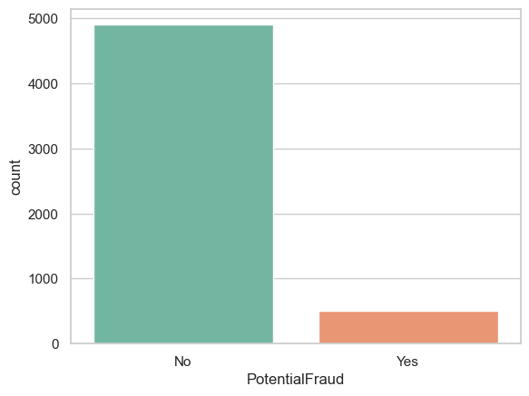

```python
# Check the distribution of the target variable
sns.countplot(x='PotentialFraud',data=data, palette='Set2')
```

# Conclusion

Dataset is imbalanced

# 5a . Percentage of fraudulent encounters Inpatient / Outpatient

```python
# Now we will filter out only the fraudulent providers to analyze their characteristics in more detail.

only_fraud_provider = data.loc[data['PotentialFraud']=='Yes']
print("Dataset shape : ", only_fraud_provider.shape)
only_fraud_provider.head(5)
```

```
Dataset shape :  (506, 2)
```

|  | Provider | PotentialFraud |
| --- | --- | --- |
| 1 | PRV51003 | Yes |
| 3 | PRV51005 | Yes |
| 13 | PRV51021 | Yes |
| 25 | PRV51037 | Yes |
| 37 | PRV51052 | Yes |

```python
# Now we will merge this dataset with the Inpatient and Outpatient datasets to analyze the characteristics of fraudulent providers in more detail.

fraud_provider_inpatient_df = pd.merge(data_inpatient, only_fraud_provider, how='inner', on='Provider')
print("Dataset shape : ", fraud_provider_inpatient_df.shape)
fraud_provider_inpatient_df.head(5)
```

```
Dataset shape :  (23402, 31)
```

|  | BeneID | ClaimID | ClaimStartDt | ClaimEndDt | Provider | InscClaimAmtReimbursed | AttendingPhysician | OperatingPhysician | OtherPhysician | AdmissionDt | ... | ClmDiagnosisCode_8 | ClmDiagnosisCode_9 | ClmDiagnosisCode_10 | ClmProcedureCode_1 | ClmProcedureCode_2 | ClmProcedureCode_3 | ClmProcedureCode_4 | ClmProcedureCode_5 | ClmProcedureCode_6 | PotentialFraud |
| --- | --- | --- | --- | --- | --- | --- | --- | --- | --- | --- | --- | --- | --- | --- | --- | --- | --- | --- | --- | --- | --- |
| 0 | BENE11001 | CLM46614 | 2009-04-12 | 2009-04-18 | PRV55912 | 26000 | PHY390922 | NaN | NaN | 2009-04-12 | ... | 19889 | 5849 | NaN | NaN | NaN | NaN | NaN | NaN | NaN | Yes |
| 1 | BENE11017 | CLM70950 | 2009-10-06 | 2009-10-12 | PRV54986 | 8000 | PHY402711 | PHY402711 | PHY402711 | 2009-10-06 | ... | 25000 | 25002 | NaN | 863.0 | NaN | NaN | NaN | NaN | NaN | Yes |
| 2 | BENE11028 | CLM62376 | 2009-08-03 | 2009-08-07 | PRV51148 | 6000 | PHY346286 | PHY405514 | NaN | 2009-08-03 | ... | 4439 | 41401 | NaN | 9904.0 | NaN | NaN | NaN | NaN | NaN | Yes |
| 3 | BENE11034 | CLM31519 | 2008-12-29 | 2009-01-05 | PRV55215 | 29000 | PHY355604 | PHY415867 | NaN | 2008-12-29 | ... | 4111 | 4589 | NaN | 3612.0 | 4139.0 | NaN | NaN | NaN | NaN | Yes |
| 4 | BENE11034 | CLM57949 | 2009-07-01 | 2009-07-09 | PRV55193 | 102000 | PHY397979 | PHY418257 | NaN | 2009-07-01 | ... | 591 | 51881 | NaN | 9672.0 | NaN | NaN | NaN | NaN | NaN | Yes |

5 rows × 31 columns

```python
# Now we will check what percentage of the inpatient data is related to fraudulent providers.

print("Dataset shape : ", fraud_provider_inpatient_df.shape)
print("Percentage of fraud cases related to inpatient data : ",(fraud_provider_inpatient_df.shape[0]/data_inpatient.shape[0])*100)
```

```
Dataset shape :  (23402, 31)
Percentage of fraud cases related to inpatient data :  57.81983495577408
```

# Conclusion

Around 58 % of the inpatient data for training has fraudulent encounter

```python
# Now we will check what percentage of the outpatient data is related to fraudulent providers.

fraud_provider_outpatient_df = pd.merge(data_outpatient, only_fraud_provider, how='inner', on='Provider')
print("Dataset shape : ", fraud_provider_outpatient_df.shape)
fraud_provider_outpatient_df.head(5)
```

```
Dataset shape :  (189394, 29)
```

|  | BeneID | ClaimID | ClaimStartDt | ClaimEndDt | Provider | InscClaimAmtReimbursed | AttendingPhysician | OperatingPhysician | OtherPhysician | ClmDiagnosisCode_1 | ... | ClmProcedureCode_1 | ClmProcedureCode_2 | ClmProcedureCode_3 | ClmProcedureCode_4 | ClmProcedureCode_5 | ClmProcedureCode_6 | DeductibleAmtPaid | ClmAdmitDiagnosisCode | Physician_Team | PotentialFraud |
| --- | --- | --- | --- | --- | --- | --- | --- | --- | --- | --- | --- | --- | --- | --- | --- | --- | --- | --- | --- | --- | --- |
| 0 | BENE11002 | CLM624349 | 2009-10-11 | 2009-10-11 | PRV56011 | 30 | PHY326117 | NaN | NaN | 78943 | ... | NaN | NaN | NaN | NaN | NaN | NaN | 0 | 56409 | NaN | Yes |
| 1 | BENE11004 | CLM121801 | 2009-01-06 | 2009-01-06 | PRV56011 | 40 | PHY334319 | NaN | NaN | 71988 | ... | NaN | NaN | NaN | NaN | NaN | NaN | 0 | NaN | NaN | Yes |
| 2 | BENE11004 | CLM150998 | 2009-01-22 | 2009-01-22 | PRV56011 | 200 | PHY403831 | NaN | NaN | 82382 | ... | NaN | NaN | NaN | NaN | NaN | NaN | 0 | 71947 | NaN | Yes |
| 3 | BENE11004 | CLM173224 | 2009-02-03 | 2009-02-03 | PRV56011 | 20 | PHY339887 | NaN | NaN | 20381 | ... | NaN | NaN | NaN | NaN | NaN | NaN | 0 | NaN | NaN | Yes |
| 4 | BENE11004 | CLM224741 | 2009-03-03 | 2009-03-03 | PRV56011 | 40 | PHY345721 | NaN | NaN | V6546 | ... | NaN | NaN | NaN | NaN | NaN | NaN | 0 | NaN | NaN | Yes |

5 rows × 29 columns

```python
# Now we will check what percentage of the outpatient data is related to fraudulent providers.

print("Dataset shape : ", fraud_provider_outpatient_df.shape)
print("Percentage of fraud cases related to outpatient data : ",(fraud_provider_outpatient_df.shape[0]/data_outpatient.shape[0])*100)
```

```
Dataset shape :  (189394, 29)
Percentage of fraud cases related to outpatient data :  36.58112130290089
```

# Conclusion

Around 37 % of the outpatient data for training has fraudulent encounter

# 5b . 20 Most used procedure codes and diagnosis codes used by the potential fraudulent providers

# Inpatient - Procedure

```
(17325, 1)
```

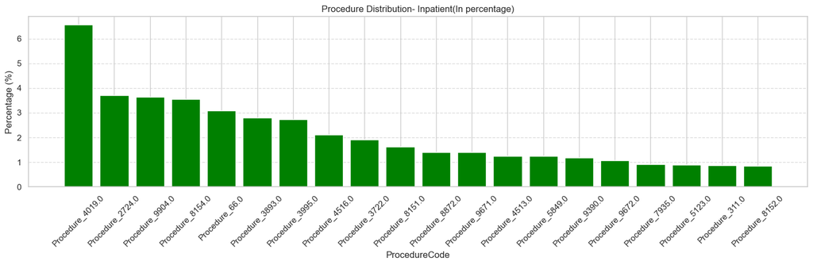

```python
#create a dataframe for concatenating all Procedure Code columns

inpatient_df = pd.DataFrame(columns = ['ProcedureCode'])
inpatient_df['ProcedureCode'] = pd.concat([fraud_provider_inpatient_df["ClmProcedureCode_1"],
                                           fraud_provider_inpatient_df["ClmProcedureCode_2"],
                                           fraud_provider_inpatient_df["ClmProcedureCode_3"],
                                           fraud_provider_inpatient_df["ClmProcedureCode_4"],
                                           fraud_provider_inpatient_df["ClmProcedureCode_5"],
                                           fraud_provider_inpatient_df["ClmProcedureCode_6"]], axis=0, sort=True).dropna()

print(inpatient_df.shape)

analyse_cat_columns(inpatient_df,col_to_analyse='ProcedureCode' , prefix = 'Procedure_',title = 'Procedure Distribution- Inpatient(In percentage)',top_val = 20)
```

```
(189329, 1)
```

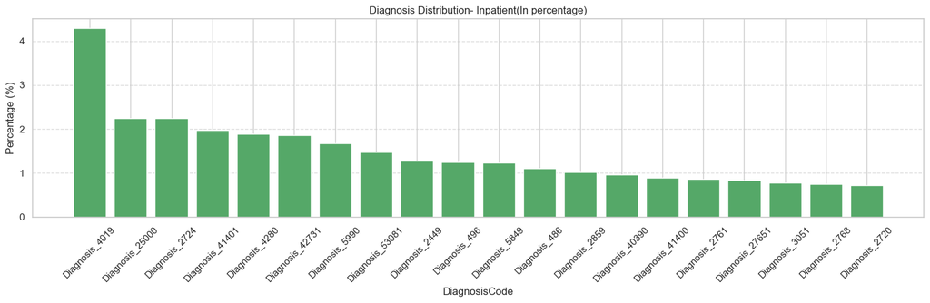

```python
#create a dataframe for concatenating all DiagnosisCode Code columns

inpatient_df = pd.DataFrame(columns = ['DiagnosisCode'])
inpatient_df['DiagnosisCode'] = pd.concat([fraud_provider_inpatient_df["ClmDiagnosisCode_1"],
                                           fraud_provider_inpatient_df["ClmDiagnosisCode_2"],
                                           fraud_provider_inpatient_df["ClmDiagnosisCode_3"],
                                           fraud_provider_inpatient_df["ClmDiagnosisCode_4"],
                                           fraud_provider_inpatient_df["ClmDiagnosisCode_5"],
                                           fraud_provider_inpatient_df["ClmDiagnosisCode_6"],
                                           fraud_provider_inpatient_df["ClmDiagnosisCode_7"],
                                           fraud_provider_inpatient_df["ClmDiagnosisCode_8"],
                                           fraud_provider_inpatient_df["ClmDiagnosisCode_9"],
                                           fraud_provider_inpatient_df["ClmDiagnosisCode_10"]], axis=0, sort=True).dropna()

print(inpatient_df.shape)

analyse_cat_columns(inpatient_df,col_to_analyse='DiagnosisCode' , prefix = 'Diagnosis_',title = 'Diagnosis Distribution- Inpatient(In percentage)',top_val = 20 ,color = 'g')
```

```
(96, 1)
```

[figure not shown]

```python
#create a dataframe for concatenating all Procedure Code columns

inpatient_df = pd.DataFrame(columns = ['ProcedureCode'])
inpatient_df['ProcedureCode'] = pd.concat([fraud_provider_outpatient_df["ClmProcedureCode_1"],
                                           fraud_provider_outpatient_df["ClmProcedureCode_2"],
                                           fraud_provider_outpatient_df["ClmProcedureCode_3"],
                                           fraud_provider_outpatient_df["ClmProcedureCode_4"],
                                           fraud_provider_inpatient_df["ClmProcedureCode_5"],
                                           fraud_provider_outpatient_df["ClmProcedureCode_6"]], axis=0, sort=True).dropna()

print(inpatient_df.shape)

analyse_cat_columns(inpatient_df,col_to_analyse='ProcedureCode' , prefix = 'Procedure_',title = 'Procedure Distribution- Inpatient(In percentage)',top_val = 20)
```

```
(494869, 1)
```

[figure not shown]

```python
#create a dataframe for concatenating all DiagnosisCode Code columns

inpatient_df = pd.DataFrame(columns = ['DiagnosisCode'])
inpatient_df['DiagnosisCode'] = pd.concat([fraud_provider_outpatient_df["ClmDiagnosisCode_1"],
                                           fraud_provider_outpatient_df["ClmDiagnosisCode_2"],
                                           fraud_provider_outpatient_df["ClmDiagnosisCode_3"],
                                           fraud_provider_outpatient_df["ClmDiagnosisCode_4"],
                                           fraud_provider_outpatient_df["ClmDiagnosisCode_5"],
                                           fraud_provider_outpatient_df["ClmDiagnosisCode_6"],
                                           fraud_provider_outpatient_df["ClmDiagnosisCode_7"],
                                           fraud_provider_outpatient_df["ClmDiagnosisCode_8"],
                                           fraud_provider_outpatient_df["ClmDiagnosisCode_9"],
                                           fraud_provider_outpatient_df["ClmDiagnosisCode_10"]], axis=0, sort=True).dropna()

print(inpatient_df.shape)

analyse_cat_columns(inpatient_df,col_to_analyse='DiagnosisCode' , prefix = 'Diagnosis_',title = 'Diagnosis Distribution- Inpatient(In percentage)',top_val = 20 ,color = 'g')
```

# 6. Gaining Insights from beneficiary Data

```python
#check all the columns of the beneficiary dataset and top 5 data points

print('Columns in this dataset are : ')
print(data_beneficiary.columns)

data_beneficiary.head(2)
```

```
Columns in this dataset are :
Index(['BeneID', 'DOB', 'DOD', 'Gender', 'Race', 'RenalDiseaseIndicator',
       'State', 'County', 'NoOfMonths_PartACov', 'NoOfMonths_PartBCov',
       'ChronicCond_Alzheimer', 'ChronicCond_Heartfailure',
       'ChronicCond_KidneyDisease', 'ChronicCond_Cancer',
       'ChronicCond_ObstrPulmonary', 'ChronicCond_Depression',
       'ChronicCond_Diabetes', 'ChronicCond_IschemicHeart',
       'ChronicCond_Osteoporasis', 'ChronicCond_rheumatoidarthritis',
       'ChronicCond_stroke', 'IPAnnualReimbursementAmt',
       'IPAnnualDeductibleAmt', 'OPAnnualReimbursementAmt',
       'OPAnnualDeductibleAmt'],
      dtype='object')
```

|  | BeneID | DOB | DOD | Gender | Race | RenalDiseaseIndicator | State | County | NoOfMonths_PartACov | NoOfMonths_PartBCov | ... | ChronicCond_Depression | ChronicCond_Diabetes | ChronicCond_IschemicHeart | ChronicCond_Osteoporasis | ChronicCond_rheumatoidarthritis | ChronicCond_stroke | IPAnnualReimbursementAmt | IPAnnualDeductibleAmt | OPAnnualReimbursementAmt | OPAnnualDeductibleAmt |
| --- | --- | --- | --- | --- | --- | --- | --- | --- | --- | --- | --- | --- | --- | --- | --- | --- | --- | --- | --- | --- | --- |
| 0 | BENE11001 | 1943-01-01 | NaN | 1 | 1 | 0 | 39 | 230 | 12 | 12 | ... | 1 | 1 | 1 | 2 | 1 | 1 | 36000 | 3204 | 60 | 70 |
| 1 | BENE11002 | 1936-09-01 | NaN | 2 | 1 | 0 | 39 | 280 | 12 | 12 | ... | 2 | 2 | 2 | 2 | 2 | 2 | 0 | 0 | 30 | 50 |

2 rows × 25 columns

# 6a . State and County

```python
# Now we will merge the beneficiary dataset with the inpatient dataset to analyze the characteristics of beneficiaries related to
# fraudulent providers in more detail.

bene_inpat_df = pd.merge(data_beneficiary, fraud_provider_inpatient_df, how='inner', on='BeneID')
print(bene_inpat_df.shape)
bene_inpat_df.head(5)
```

```
(23402, 55)
```

|  | BeneID | DOB | DOD | Gender | Race | RenalDiseaseIndicator | State | County | NoOfMonths_PartACov | NoOfMonths_PartBCov | ... | ClmDiagnosisCode_8 | ClmDiagnosisCode_9 | ClmDiagnosisCode_10 | ClmProcedureCode_1 | ClmProcedureCode_2 | ClmProcedureCode_3 | ClmProcedureCode_4 | ClmProcedureCode_5 | ClmProcedureCode_6 | PotentialFraud |
| --- | --- | --- | --- | --- | --- | --- | --- | --- | --- | --- | --- | --- | --- | --- | --- | --- | --- | --- | --- | --- | --- |
| 0 | BENE11001 | 1943-01-01 | NaN | 1 | 1 | 0 | 39 | 230 | 12 | 12 | ... | 19889 | 5849 | NaN | NaN | NaN | NaN | NaN | NaN | NaN | Yes |
| 1 | BENE11017 | 1940-06-01 | NaN | 2 | 1 | 0 | 31 | 270 | 12 | 12 | ... | 25000 | 25002 | NaN | 863.0 | NaN | NaN | NaN | NaN | NaN | Yes |
| 2 | BENE11028 | 1941-12-01 | NaN | 1 | 1 | 0 | 38 | 230 | 12 | 12 | ... | 4439 | 41401 | NaN | 9904.0 | NaN | NaN | NaN | NaN | NaN | Yes |
| 3 | BENE11034 | 1946-03-01 | NaN | 2 | 1 | 0 | 34 | 760 | 12 | 12 | ... | 4111 | 4589 | NaN | 3612.0 | 4139.0 | NaN | NaN | NaN | NaN | Yes |
| 4 | BENE11034 | 1946-03-01 | NaN | 2 | 1 | 0 | 34 | 760 | 12 | 12 | ... | 591 | 51881 | NaN | 9672.0 | NaN | NaN | NaN | NaN | NaN | Yes |

5 rows × 55 columns

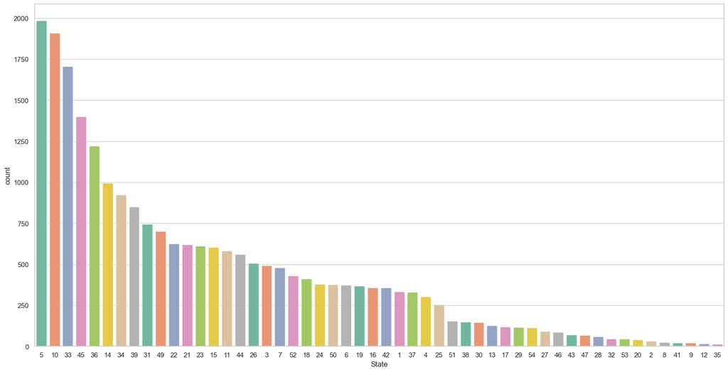

```python
# Now we will merge the beneficiary dataset with the inpatient dataset to analyze the characteristics of beneficiaries related to
# fraudulent providers in more detail.

plt.figure(figsize=(20, 10))
sns.countplot(x='State',y=None, data=bene_inpat_df, orient ="v", order = bene_inpat_df['State'].value_counts().index, palette='Set2')
```

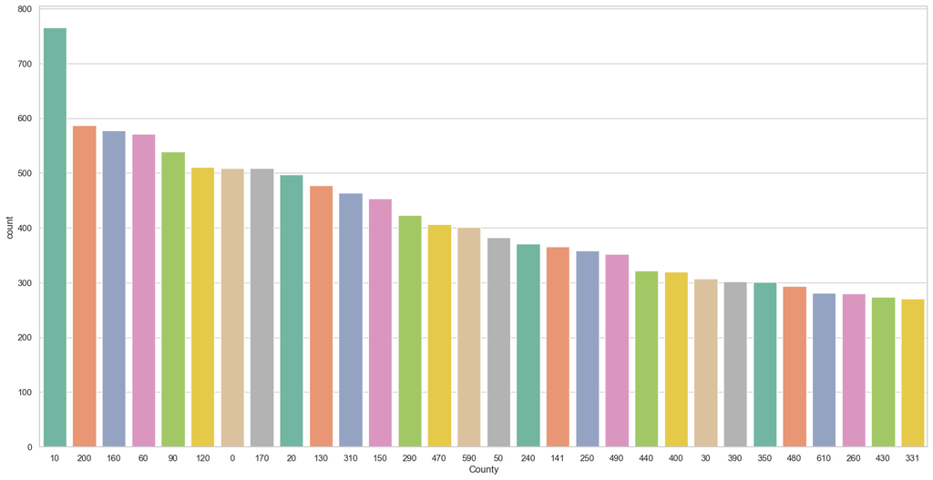

```python
# Now we will merge the beneficiary dataset with the inpatient dataset to analyze the characteristics of beneficiaries related to
# fraudulent providers in more detail.
plt.figure(figsize=(20, 10))
sns.countplot(x='County',y=None, data=bene_inpat_df, orient ="v", order = bene_inpat_df['County'].value_counts().head(30).index, palette='Set2')
```

# Conclusion

### Inpatient + fraud -- State

State coded as 5,10,33 and 45 have most fraudulent encounters for Inpatient data . County coded as 10,200,160 and 60 have most fraudulent encounters for Inpatient data .

# Outpatient + Fraud -- State

```python
# Now we will merge the beneficiary dataset with the outpatient dataset to analyze the characteristics of beneficiaries related to
# fraudulent providers in more detail.

bene_outpat_df = pd.merge(data_beneficiary, fraud_provider_outpatient_df, how='inner', on='BeneID')
print(bene_outpat_df.shape)
bene_outpat_df.head(5)
```

```
(189394, 53)
```

|  | BeneID | DOB | DOD | Gender | Race | RenalDiseaseIndicator | State | County | NoOfMonths_PartACov | NoOfMonths_PartBCov | ... | ClmProcedureCode_1 | ClmProcedureCode_2 | ClmProcedureCode_3 | ClmProcedureCode_4 | ClmProcedureCode_5 | ClmProcedureCode_6 | DeductibleAmtPaid | ClmAdmitDiagnosisCode | Physician_Team | PotentialFraud |
| --- | --- | --- | --- | --- | --- | --- | --- | --- | --- | --- | --- | --- | --- | --- | --- | --- | --- | --- | --- | --- | --- |
| 0 | BENE11002 | 1936-09-01 | NaN | 2 | 1 | 0 | 39 | 280 | 12 | 12 | ... | NaN | NaN | NaN | NaN | NaN | NaN | 0 | 56409 | NaN | Yes |
| 1 | BENE11004 | 1922-07-01 | NaN | 1 | 1 | 0 | 39 | 270 | 12 | 12 | ... | NaN | NaN | NaN | NaN | NaN | NaN | 0 | NaN | NaN | Yes |
| 2 | BENE11004 | 1922-07-01 | NaN | 1 | 1 | 0 | 39 | 270 | 12 | 12 | ... | NaN | NaN | NaN | NaN | NaN | NaN | 0 | 71947 | NaN | Yes |
| 3 | BENE11004 | 1922-07-01 | NaN | 1 | 1 | 0 | 39 | 270 | 12 | 12 | ... | NaN | NaN | NaN | NaN | NaN | NaN | 0 | NaN | NaN | Yes |
| 4 | BENE11004 | 1922-07-01 | NaN | 1 | 1 | 0 | 39 | 270 | 12 | 12 | ... | NaN | NaN | NaN | NaN | NaN | NaN | 0 | NaN | NaN | Yes |

5 rows × 53 columns

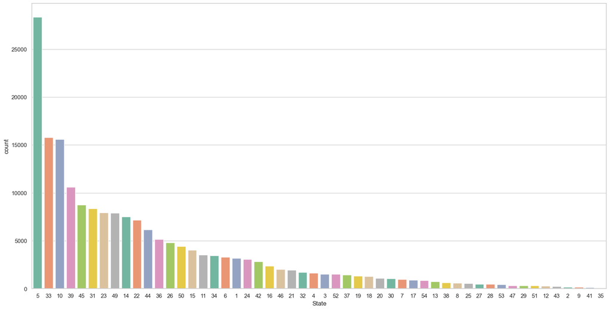

```python
# Now we will merge the beneficiary dataset with the outpatient dataset to analyze the characteristics of beneficiaries related to
# fraudulent providers in more detail.

plt.figure(figsize=(20, 10))
sns.countplot(x='State',y=None, data=bene_outpat_df, orient ="v", order = bene_outpat_df['State'].value_counts().index, palette='Set2')
```

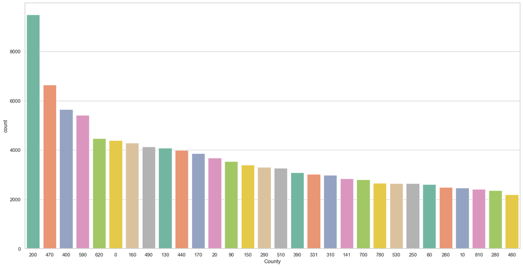

```python
# Now we will merge the beneficiary dataset with the outpatient dataset to analyze the characteristics of beneficiaries related to
# fraudulent providers in more detail.

plt.figure(figsize=(20, 10))
sns.countplot(x='County',y=None, data=bene_outpat_df, orient ="v", order = bene_outpat_df['County'].value_counts().head(30).index, palette='Set2')
```

# Conclusion

# 6b . DOB

## Inpatient + Fraud - DOB

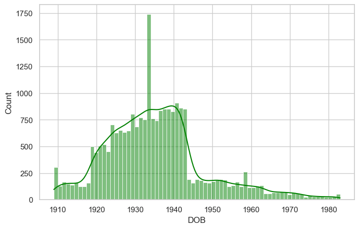

```python
# Ensure DOB is a datetime type (if not already)
bene_inpat_df['DOB'] = pd.to_datetime(bene_inpat_df['DOB'])

# histogram of birth years to see the age distribution of beneficiaries associated with fraudulent providers
plt.figure(figsize=(8, 5))
sns.histplot(bene_inpat_df.DOB.apply(get_year), kde=True, color='green')
```

# Conclusion

### Inpatient + Fraud - DOB

Most Fraudulent encounters in Inpatient Data is observed for the patients born between 1920 and 1945

## Outpatient + Fraud - DOB

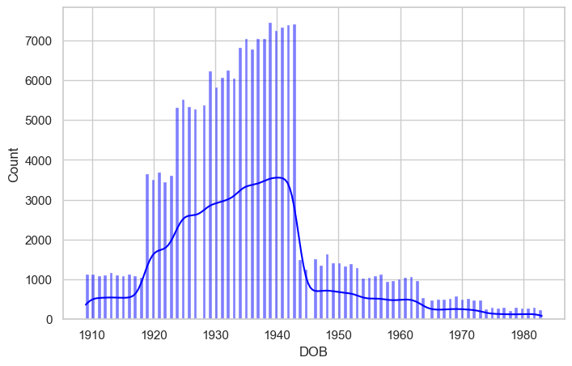

```python
# Ensure DOB is a datetime type (if not already)
bene_outpat_df['DOB'] = pd.to_datetime(bene_outpat_df['DOB'])

# histogram of birth years to see the age distribution of beneficiaries associated with fraudulent providers
plt.figure(figsize=(8, 5))
sns.histplot(bene_outpat_df.DOB.apply(get_year), kde=True, color='blue')
```

# Conclusion

### Outpatient + Fraud - DOB

# 7. Calculating Money lost in Fraud for both Inpatient and outpatinet data

```python
# Now we will merge the beneficiary dataset with the inpatient dataset to analyze the characteristics of beneficiaries related to
# fraudulent providers in more detail.

inpat_labeled_provider_df = pd.merge(data_inpatient , data , how='inner', on='Provider')
print(inpat_labeled_provider_df.shape)
```

```
(40474, 31)
```

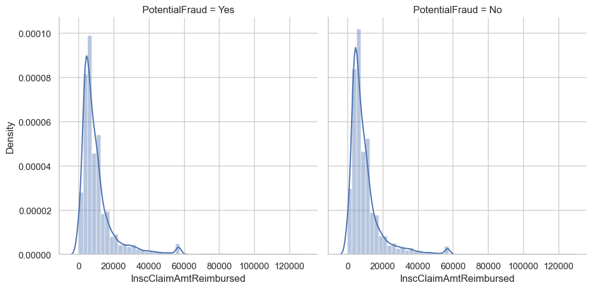

```python
# Now we will merge the beneficiary dataset with the inpatient dataset to analyze the characteristics of beneficiaries related to
# fraudulent providers in more detail.

sns.FacetGrid(inpat_labeled_provider_df, col='PotentialFraud',height=5).map(sns.distplot, "InscClaimAmtReimbursed",).add_legend()
plt.show()
plt.tight_layout()
```

```python
# calculating total money lost inpatient fraudulent encounters

Total_money_lost = inpat_labeled_provider_df.loc[inpat_labeled_provider_df['PotentialFraud']== 'Yes'].InscClaimAmtReimbursed.sum()

print("Total money lost : ",Total_money_lost)
```

```
Total money lost :  241288510
```

```python
# calculating total money lost outpatient fraudulent encounters

outpat_labeled_provider_df = pd.merge(data_outpatient , data , how='inner', on='Provider')
print(outpat_labeled_provider_df.shape)
```

```
(517737, 29)
```

```python
# calculating total money lost in outpatient fraudulent encounters
Total_money_lost = outpat_labeled_provider_df.loc[outpat_labeled_provider_df['PotentialFraud']== 'Yes'].InscClaimAmtReimbursed.sum()

print("Total money lost : ",Total_money_lost)
```

```
Total money lost :  54392610
```

```python
print('Total money lost as per the data = ','241,288,510 + 54,392,610, That is around 295 Million' )
```

```
Total money lost as per the data =  241,288,510 + 54,392,610, That is around 295 Million
```

Till this point we have done thorough EDA on columns of each of the data files. Now we will merge them all and then perform EDA to establish a trend in data and the target.

# 8 . Data preprocessing and Feature Engineering

```python
# Create a binary target variable for whether the claim was admitted (inpatient) or not (outpatient)

data_inpatient['is_admitted'] = 1
data_outpatient['is_admitted'] = 0
```

```python
# Merge in_pt, out_pt and ben df into a single patient dataset
data1 = pd.merge(data_inpatient, data_outpatient,
                    left_on = [ idx for idx in data_outpatient.columns if idx in data_inpatient.columns],
                    right_on = [ idx for idx in data_outpatient.columns if idx in data_inpatient.columns],
                    how = 'outer').\
          merge(data_beneficiary,left_on='BeneID',right_on='BeneID',how='inner')
```

```python
# Replace values with a binary annotation

data1 = data1.replace({'ChronicCond_Alzheimer': 2, 'ChronicCond_Heartfailure': 2, 'ChronicCond_KidneyDisease': 2,
                   'ChronicCond_Cancer': 2, 'ChronicCond_ObstrPulmonary': 2, 'ChronicCond_Depression': 2,
                   'ChronicCond_Diabetes': 2, 'ChronicCond_IschemicHeart': 2, 'ChronicCond_Osteoporasis': 2,
                   'ChronicCond_rheumatoidarthritis': 2, 'ChronicCond_stroke': 2, 'Gender': 2 },
                  0)
```

```python
# data1.RenalDiseaseIndicator.unique() #array(['0', 'Y'], dtype=object)
# Replace values with a binary annotation

data1 = data1.replace({'RenalDiseaseIndicator': 'Y'}, 1).astype({'RenalDiseaseIndicator': 'int64'})#array([0, 1], dtype=int64)
```

```python
#merging the dataset created in above step with data
data_final = pd.merge(data1, data , how = 'outer', on = 'Provider' )
```

```python
# adding extra column target, having binary annotation
data_final['target'] = data_final['PotentialFraud']

# representing potential fraud and 0 representing non potential fraud
data_final['target'] = data_final['target'].map({"Yes":1,"No":0})
data_final['target'] = data_final['target'].astype('category',copy=False)
```

```
PotentialFraud
No     345415
Yes    212796
Name: count, dtype: int64
```

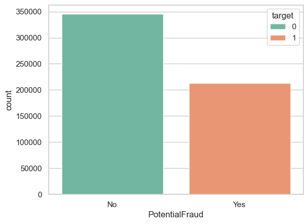

```python
# checking the distribution of target variable in the final dataset

print(data_final.PotentialFraud.value_counts())
sns.countplot(x='PotentialFraud', data=data_final, palette='Set2', hue='target' )
```

```python
# Now we have a final dataset with all the features from inpatient, outpatient and beneficiary datasets,
# along with the target variable indicating potential fraud. We can now proceed to build machine learning models to predict fraudulent providers based on these features.

print(data_final.shape)
data_final.head(5)
```

```
(558211, 58)
```

|  | BeneID | ClaimID | ClaimStartDt | ClaimEndDt | Provider | InscClaimAmtReimbursed | AttendingPhysician | OperatingPhysician | OtherPhysician | AdmissionDt | ... | ChronicCond_IschemicHeart | ChronicCond_Osteoporasis | ChronicCond_rheumatoidarthritis | ChronicCond_stroke | IPAnnualReimbursementAmt | IPAnnualDeductibleAmt | OPAnnualReimbursementAmt | OPAnnualDeductibleAmt | PotentialFraud | target |
| --- | --- | --- | --- | --- | --- | --- | --- | --- | --- | --- | --- | --- | --- | --- | --- | --- | --- | --- | --- | --- | --- |
| 0 | BENE102690 | CLM49733 | 2009-05-04 | 2009-05-18 | PRV51001 | 42000 | PHY383193 | PHY378091 | PHY389113 | 2009-05-04 | ... | 1 | 0 | 1 | 0 | 143800 | 4272 | 880 | 70 | No | 0 |
| 1 | BENE106078 | CLM419490 | 2009-06-16 | 2009-06-16 | PRV51001 | 90 | PHY345302 | NaN | NaN | NaN | ... | 1 | 0 | 0 | 0 | 0 | 0 | 190 | 20 | No | 0 |
| 2 | BENE11727 | CLM733300 | 2009-12-17 | 2009-12-17 | PRV51001 | 20 | PHY383007 | NaN | PHY383007 | NaN | ... | 1 | 0 | 0 | 0 | 0 | 0 | 300 | 110 | No | 0 |
| 3 | BENE123416 | CLM172987 | 2009-02-02 | 2009-02-02 | PRV51001 | 100 | PHY345302 | NaN | PHY345302 | NaN | ... | 1 | 0 | 0 | 0 | 0 | 0 | 3600 | 10 | No | 0 |
| 4 | BENE126477 | CLM361230 | 2009-05-15 | 2009-05-15 | PRV51001 | 200 | PHY354616 | PHY405310 | PHY405310 | NaN | ... | 1 | 0 | 1 | 0 | 0 | 0 | 690 | 150 | No | 0 |

5 rows × 58 columns

```python
#check columns for NaN values

data_final.isna().sum()
```

```
BeneID                                  0
ClaimID                                 0
ClaimStartDt                            0
ClaimEndDt                              0
Provider                                0
InscClaimAmtReimbursed                  0
AttendingPhysician                   1508
OperatingPhysician                 443764
OtherPhysician                     358475
AdmissionDt                        517737
ClmAdmitDiagnosisCode              412312
DeductibleAmtPaid                     899
DischargeDt                        517737
DiagnosisGroupCode                 517737
ClmDiagnosisCode_1                  10453
ClmDiagnosisCode_2                 195606
ClmDiagnosisCode_3                 315156
ClmDiagnosisCode_4                 393675
ClmDiagnosisCode_5                 446287
ClmDiagnosisCode_6                 473819
ClmDiagnosisCode_7                 492034
ClmDiagnosisCode_8                 504767
ClmDiagnosisCode_9                 516396
ClmDiagnosisCode_10                553201
ClmProcedureCode_1                 534901
ClmProcedureCode_2                 552721
ClmProcedureCode_3                 557242
ClmProcedureCode_4                 558093
ClmProcedureCode_5                 558202
ClmProcedureCode_6                 558211
is_admitted                             0
Physician_Team                     467602
DOB                                     0
DOD                                554080
Gender                                  0
Race                                    0
RenalDiseaseIndicator                   0
State                                   0
County                                  0
NoOfMonths_PartACov                     0
NoOfMonths_PartBCov                     0
ChronicCond_Alzheimer                   0
ChronicCond_Heartfailure                0
ChronicCond_KidneyDisease               0
ChronicCond_Cancer                      0
ChronicCond_ObstrPulmonary              0
ChronicCond_Depression                  0
ChronicCond_Diabetes                    0
ChronicCond_IschemicHeart               0
ChronicCond_Osteoporasis                0
ChronicCond_rheumatoidarthritis         0
ChronicCond_stroke                      0
IPAnnualReimbursementAmt                0
IPAnnualDeductibleAmt                   0
OPAnnualReimbursementAmt                0
OPAnnualDeductibleAmt                   0
PotentialFraud                          0
target                                  0
dtype: int64
```

```python
#Adding a column is_dead  = 1  DOD is given else is_dead = 0

data_final.loc[data_final['DOD'].isnull(), 'Is_Dead'] = '0'
data_final.loc[(data_final['DOD'].notnull()), 'Is_Dead'] = '1'
```

As we have DOD for only few BeneID,so we can only determine the eaxct age of the patinets who has died.we cannot get the age of the patonets who might be alive.So its better that we calculate the age of the patient when we submiited his claim as we have record for ClaimStartDt

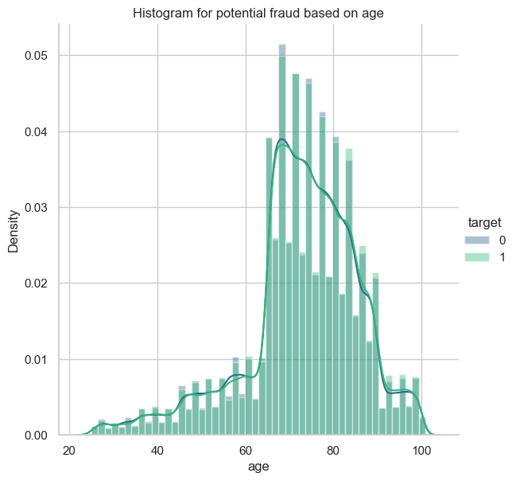

```python
# Now we will analyze the age distribution of beneficiaries associated with fraudulent providers.
# We will calculate the age of beneficiaries at the time of claim and plot the distribution of age for potential fraud and non potential fraud cases.

data_final['DOB'] =  pd.to_datetime(data_final['DOB'], format='%Y-%m-%d')
data_final['ClaimStartDt'] = pd.to_datetime(data_final['ClaimStartDt'], format='%Y-%m-%d')

#now = pd.to_datetime('2020-09-01' , format = '%Y-%m-%d')
data_final['DOB'] = data_final['DOB'].where(data_final['DOB'] < data_final['ClaimStartDt'])
#data_final['age'] = (data_final['ClaimStartDt'] - data_final['DOB']).astype('<m8[Y]')
data_final['age'] = (data_final['ClaimStartDt'] - data_final['DOB']).dt.days // 365


#plotting age
sns.FacetGrid(data_final, hue="target" , height=6, palette='viridis').map(sns.distplot, "age",).add_legend()
plt.title('Histogram for potential fraud based on age')
plt.show()
plt.tight_layout()
```

# Age

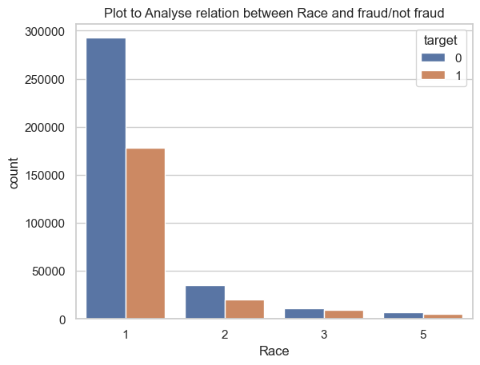

```python
# Now we will analyze the relationship between Race and potential fraud cases in the dataset.

ax = sns.countplot(x='Race',data=data_final,hue='target')
ax.set_title("Plot to Analyse relation between Race and fraud/not fraud")
```

# Conclusion

It is very important to see that most fraudulent cases is with patients belonging to a particular Race and that is labelled as 1

```python
# Since we didn't have any use for DOD and DOB columns in our analysis, we will drop these columns from the final dataset.

data_final = data_final.drop(['DOD'], axis = 1)
data_final = data_final.drop(['DOB'], axis = 1)
```

```python
#calculating number of days a patient was admitted in the hospital and then removing admit and discharge date
#outpatients dont get admitted so we keep 0 for them


data_final['AdmissionDt'] = pd.to_datetime(data_final['AdmissionDt'] , format = '%Y-%m-%d')
data_final['DischargeDt'] = pd.to_datetime(data_final['DischargeDt'],format = '%Y-%m-%d')
data_final['Num_admit_days'] = ((data_final['DischargeDt'] - data_final['AdmissionDt']).dt.days)+1
data_final.loc[data_final['is_admitted'] == 0, 'Num_admit_days'] = '0'

data_final = data_final.drop(['DischargeDt'], axis = 1)
data_final = data_final.drop(['AdmissionDt'], axis = 1)
```

```python
#check columns for NaN values
data_final.isna().sum()
```

```
BeneID                                  0
ClaimID                                 0
ClaimStartDt                            0
ClaimEndDt                              0
Provider                                0
InscClaimAmtReimbursed                  0
AttendingPhysician                   1508
OperatingPhysician                 443764
OtherPhysician                     358475
ClmAdmitDiagnosisCode              412312
DeductibleAmtPaid                     899
DiagnosisGroupCode                 517737
ClmDiagnosisCode_1                  10453
ClmDiagnosisCode_2                 195606
ClmDiagnosisCode_3                 315156
ClmDiagnosisCode_4                 393675
ClmDiagnosisCode_5                 446287
ClmDiagnosisCode_6                 473819
ClmDiagnosisCode_7                 492034
ClmDiagnosisCode_8                 504767
ClmDiagnosisCode_9                 516396
ClmDiagnosisCode_10                553201
ClmProcedureCode_1                 534901
ClmProcedureCode_2                 552721
ClmProcedureCode_3                 557242
ClmProcedureCode_4                 558093
ClmProcedureCode_5                 558202
ClmProcedureCode_6                 558211
is_admitted                             0
Physician_Team                     467602
Gender                                  0
Race                                    0
RenalDiseaseIndicator                   0
State                                   0
County                                  0
NoOfMonths_PartACov                     0
NoOfMonths_PartBCov                     0
ChronicCond_Alzheimer                   0
ChronicCond_Heartfailure                0
ChronicCond_KidneyDisease               0
ChronicCond_Cancer                      0
ChronicCond_ObstrPulmonary              0
ChronicCond_Depression                  0
ChronicCond_Diabetes                    0
ChronicCond_IschemicHeart               0
ChronicCond_Osteoporasis                0
ChronicCond_rheumatoidarthritis         0
ChronicCond_stroke                      0
IPAnnualReimbursementAmt                0
IPAnnualDeductibleAmt                   0
OPAnnualReimbursementAmt                0
OPAnnualDeductibleAmt                   0
PotentialFraud                          0
target                                  0
Is_Dead                                 0
age                                     0
Num_admit_days                          0
dtype: int64
```

```python
#replacing NaN value with 0
data_final.loc[data_final['DeductibleAmtPaid'].isnull(),'DeductibleAmtPaid'] = 0
```

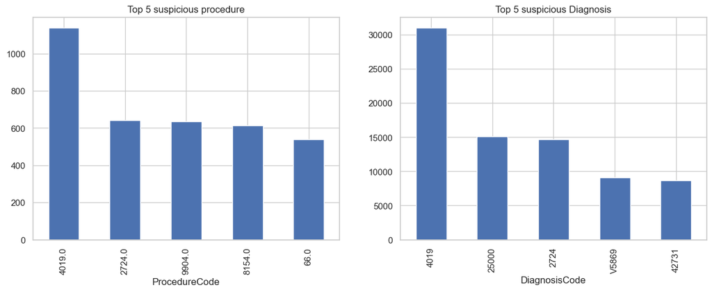

```python
# Now we will analyze the top procedure codes and diagnosis codes associated with potential fraud cases in the dataset.
# We will concatenate all the procedure code columns and diagnosis code columns into two separate dataframes
# and then plot the top 5 procedure codes and diagnosis codes associated with potential fraud cases in the dataset.

potential_fraud_df =data_final.loc[data_final['PotentialFraud'] == 'Yes']

df1 = pd.DataFrame(columns = ['ProcedureCode'])
df1['ProcedureCode'] = pd.concat([potential_fraud_df["ClmProcedureCode_1"],
                                           potential_fraud_df["ClmProcedureCode_2"],
                                           potential_fraud_df["ClmProcedureCode_3"],
                                           potential_fraud_df["ClmProcedureCode_4"],
                                           potential_fraud_df["ClmProcedureCode_5"],
                                           potential_fraud_df["ClmProcedureCode_6"]], axis=0, sort=True).dropna()

df2 = pd.DataFrame(columns = ['DiagnosisCode'])
df2['DiagnosisCode'] = pd.concat([potential_fraud_df["ClmDiagnosisCode_1"],
                                           potential_fraud_df["ClmDiagnosisCode_2"],
                                           potential_fraud_df["ClmDiagnosisCode_3"],
                                           potential_fraud_df["ClmDiagnosisCode_4"],
                                           potential_fraud_df["ClmDiagnosisCode_5"],
                                           potential_fraud_df["ClmDiagnosisCode_6"],
                                           potential_fraud_df["ClmDiagnosisCode_7"],
                                           potential_fraud_df["ClmDiagnosisCode_8"],
                                           potential_fraud_df["ClmDiagnosisCode_9"],
                                           potential_fraud_df["ClmDiagnosisCode_10"]], axis=0, sort=True).dropna()

plt.figure(figsize=(15, 5))
plt.subplot(121)
df1.ProcedureCode.value_counts().head(5).plot(kind = 'bar' , title ='Top 5 suspicious procedure')

plt.subplot(122)
df2.DiagnosisCode.value_counts().head(5).plot(kind = 'bar' , title ='Top 5 suspicious Diagnosis')
```

```python
# Defining a list of all diagnosis and procedure code columns to replace NaN values with 0

Diag_proce_col = ['ClmAdmitDiagnosisCode', 'ClmDiagnosisCode_1', 'ClmDiagnosisCode_10',
                  'ClmDiagnosisCode_2', 'ClmDiagnosisCode_3', 'ClmDiagnosisCode_4',
                  'ClmDiagnosisCode_5', 'ClmDiagnosisCode_6', 'ClmDiagnosisCode_7',
                  'ClmDiagnosisCode_8', 'ClmDiagnosisCode_9', 'ClmProcedureCode_1',
                  'ClmProcedureCode_2', 'ClmProcedureCode_3', 'ClmProcedureCode_4',
                  'ClmProcedureCode_5', 'ClmProcedureCode_6']

data_final[Diag_proce_col]= data_final[Diag_proce_col].replace({np.nan:0})
data_final.head(5)
```

|  | BeneID | ClaimID | ClaimStartDt | ClaimEndDt | Provider | InscClaimAmtReimbursed | AttendingPhysician | OperatingPhysician | OtherPhysician | ClmAdmitDiagnosisCode | ... | ChronicCond_stroke | IPAnnualReimbursementAmt | IPAnnualDeductibleAmt | OPAnnualReimbursementAmt | OPAnnualDeductibleAmt | PotentialFraud | target | Is_Dead | age | Num_admit_days |
| --- | --- | --- | --- | --- | --- | --- | --- | --- | --- | --- | --- | --- | --- | --- | --- | --- | --- | --- | --- | --- | --- |
| 0 | BENE102690 | CLM49733 | 2009-05-04 | 2009-05-18 | PRV51001 | 42000 | PHY383193 | PHY378091 | PHY389113 | 41401 | ... | 0 | 143800 | 4272 | 880 | 70 | No | 0 | 0 | 79 | 15.0 |
| 1 | BENE106078 | CLM419490 | 2009-06-16 | 2009-06-16 | PRV51001 | 90 | PHY345302 | NaN | NaN | 0 | ... | 0 | 0 | 0 | 190 | 20 | No | 0 | 0 | 80 | 0 |
| 2 | BENE11727 | CLM733300 | 2009-12-17 | 2009-12-17 | PRV51001 | 20 | PHY383007 | NaN | PHY383007 | 0 | ... | 0 | 0 | 0 | 300 | 110 | No | 0 | 0 | 79 | 0 |
| 3 | BENE123416 | CLM172987 | 2009-02-02 | 2009-02-02 | PRV51001 | 100 | PHY345302 | NaN | PHY345302 | 0 | ... | 0 | 0 | 0 | 3600 | 10 | No | 0 | 0 | 81 | 0 |
| 4 | BENE126477 | CLM361230 | 2009-05-15 | 2009-05-15 | PRV51001 | 200 | PHY354616 | PHY405310 | PHY405310 | 0 | ... | 0 | 0 | 0 | 690 | 150 | No | 0 | 0 | 69 | 0 |

5 rows × 57 columns

```python
# Now we will create new features based on the top 5 procedure codes and diagnosis codes associated with potential fraud cases in the dataset.


def encoded_cat(dataset, feature_to_encode='',col_list=[]):
    """This function returns top 5 cat column useful in determining potential fraud"""
    outer_list =[]
    for col in col_list:
        list_1 = list()

        for item in list(dataset[col]):
            if str(item) == str(feature_to_encode):
                list_1.append(1)
            else:
                list_1.append(0)

        outer_list.append(list_1)

    li_sum = np.array([0]*558211)

    for i in range(0,len(outer_list)):
        li1 = np.array(outer_list[i])
        li_sum = li_sum + li1

    return li_sum


procedure_col = ['ClmProcedureCode_1','ClmProcedureCode_2','ClmProcedureCode_3','ClmProcedureCode_4','ClmProcedureCode_5','ClmProcedureCode_6']

diagnosis_col = ['ClmDiagnosisCode_1','ClmDiagnosisCode_2','ClmDiagnosisCode_3','ClmDiagnosisCode_4','ClmDiagnosisCode_5','ClmDiagnosisCode_6','ClmDiagnosisCode_7','ClmDiagnosisCode_8','ClmDiagnosisCode_9','ClmDiagnosisCode_10']


#top 5 procedure
# 4019.0, 2724.0, 9904.0, 8154.0, 66.0
data_final['pr_4019'] = encoded_cat(data_final,'4019.0',procedure_col)
data_final['pr_2724'] = encoded_cat(data_final,'2724.0',procedure_col)
data_final['pr_9904'] = encoded_cat(data_final,'9904.0',procedure_col)
data_final['pr_8154'] = encoded_cat(data_final,'8154.0',procedure_col)
data_final['pr_66'] =   encoded_cat(data_final,'66.0',procedure_col)

#top 5 diagnosis
#4019,25000,2724,V5869,42731
data_final['di_4019'] = encoded_cat(data_final,'4019',diagnosis_col)
data_final['di_25000'] = encoded_cat(data_final,'25000',diagnosis_col)
data_final['di_2724'] = encoded_cat(data_final,'2724',diagnosis_col)
data_final['di_V5869'] = encoded_cat(data_final,'V5869',diagnosis_col)
data_final['di_42731'] =   encoded_cat(data_final,'42731',diagnosis_col)
```

```python
# Now we will replace all the values in the diagnosis and procedure code columns with binary annotations, where 1 indicates the presence of a code and 0 indicates its absence. This will help us in building machine learning models later on.


for i in Diag_proce_col:
    data_final[i][data_final[i]!=0]= 1

data_final[Diag_proce_col].head(5)
```

|  | ClmAdmitDiagnosisCode | ClmDiagnosisCode_1 | ClmDiagnosisCode_10 | ClmDiagnosisCode_2 | ClmDiagnosisCode_3 | ClmDiagnosisCode_4 | ClmDiagnosisCode_5 | ClmDiagnosisCode_6 | ClmDiagnosisCode_7 | ClmDiagnosisCode_8 | ClmDiagnosisCode_9 | ClmProcedureCode_1 | ClmProcedureCode_2 | ClmProcedureCode_3 | ClmProcedureCode_4 | ClmProcedureCode_5 | ClmProcedureCode_6 |
| --- | --- | --- | --- | --- | --- | --- | --- | --- | --- | --- | --- | --- | --- | --- | --- | --- | --- |
| 0 | 1 | 1 | 0 | 1 | 1 | 1 | 1 | 1 | 1 | 1 | 1 | 1.0 | 1.0 | 0.0 | 0.0 | 0.0 | 0.0 |
| 1 | 0 | 1 | 0 | 0 | 0 | 0 | 0 | 0 | 0 | 0 | 0 | 0.0 | 0.0 | 0.0 | 0.0 | 0.0 | 0.0 |
| 2 | 0 | 1 | 0 | 1 | 0 | 0 | 0 | 0 | 0 | 0 | 0 | 0.0 | 0.0 | 0.0 | 0.0 | 0.0 | 0.0 |
| 3 | 0 | 1 | 0 | 0 | 0 | 0 | 0 | 0 | 0 | 0 | 0 | 0.0 | 0.0 | 0.0 | 0.0 | 0.0 | 0.0 |
| 4 | 0 | 1 | 0 | 1 | 1 | 1 | 1 | 1 | 0 | 0 | 0 | 0.0 | 0.0 | 0.0 | 0.0 | 0.0 | 0.0 |

```python
# Diagnosis and procedure code columns are currently of object type, we will convert them to float type before replacing values with binary annotations.

data_final[Diag_proce_col]= data_final[Diag_proce_col].astype(float)
```

```python
#adding column total_num_diag
data_final['total_num_diag'] = 0
for col in diagnosis_col :
    data_final['total_num_diag']  = data_final['total_num_diag'] + data_final[col]
```

```python
#adding column total_num_proce

data_final['total_num_proce'] = 0
for col in procedure_col :
    data_final['total_num_proce']  = data_final['total_num_proce'] + data_final[col]
```

```python
# Now we have two new features total_num_diag and total_num_proce which represent
# the total number of diagnosis codes and procedure codes associated with each claim.
# We will convert these columns to float type before replacing values with binary annotations.

data_final['total_num_diag'] =  data_final['total_num_diag'].astype(float)
data_final['total_num_proce'] =  data_final['total_num_proce'].astype(float)
```

### Checking if we have duplicate rows

```python
#Checking we how many distinct BeneID we have in our data
#len(list(tr_data_final.BeneID.value_counts()==1))
len(list(data_final['BeneID'].unique()))
```

```
138556
```

```python
#Checking we how many distinct BeneID we have in our data
len(list(data_final['ClaimID'].unique()))
```

```
558211
```

# Conclusion

We have data for 138556 BeneID. Means one beneficiary might have applied for claim multiple times Also we have 558211 distinct claimIDs, which means we have separate record for each beneficiary every time he applied for claims No duplicate rows are present in our dataset

```python
# Now we will analyze the distribution of claims across different beneficiaries in the dataset.
# We will check how many claims are associated with each beneficiary and plot the distribution of claims per beneficiary.
val_counts_ = data_final['BeneID'].value_counts()
data_final_beneid_df = val_counts_.to_frame() #store this information in dataframe

data_final_beneid_df.columns = ['count']
data_final_beneid_df['BeneID'] = data_final_beneid_df.index
data_final_beneid_df
```

| BeneID | count | BeneID |
| --- | --- | --- |
| BENE59303 | 29 | BENE59303 |
| BENE42721 | 29 | BENE42721 |
| BENE118316 | 29 | BENE118316 |
| BENE36330 | 28 | BENE36330 |
| BENE44241 | 28 | BENE44241 |
| ... | ... | ... |
| BENE28565 | 1 | BENE28565 |
| BENE28925 | 1 | BENE28925 |
| BENE29340 | 1 | BENE29340 |
| BENE80992 | 1 | BENE80992 |
| BENE86999 | 1 | BENE86999 |

138556 rows × 2 columns

```python
# Now we will calculate the total amount reimbursed and mean amount reimbursed for each beneficiary in the dataset.

# Use a map for instant lookup
totals_map = data_final.groupby('BeneID')['InscClaimAmtReimbursed'].sum()

total_amt_list = data_final_beneid_df['BeneID'].map(totals_map).tolist()
mean_amt_list = (total_amt_list / data_final_beneid_df['count']).tolist()
```

```python
# Now we will add these two new features total_amt and mean_amt to the data_final_beneid_df dataframe which contains the count of claims for each beneficiary.

# 1. Calculate the totals from the MAIN claims data
# This creates a Series where the Index is BeneID and the values are the sums
total_reimbursements = data_final.groupby('BeneID')['InscClaimAmtReimbursed'].sum()

# 2. ADD the column to your beneficiary summary dataframe
# This maps the totals to the correct BeneID rows automatically
data_final_beneid_df['total_amt'] = data_final_beneid_df['BeneID'].map(total_reimbursements)

# 3. Handle Missing Data (Step 5 of your task)
# If a BeneID had no claims, the map results in NaN. We justify filling with 0.
data_final_beneid_df['total_amt'] = data_final_beneid_df['total_amt'].fillna(0)

# 4. Now calculate the mean (Engineering a new feature)
data_final_beneid_df['mean_amt'] = data_final_beneid_df['total_amt'] / data_final_beneid_df['count']

# 5. Extract to list (if still needed for your specific logic)
mean_list = data_final_beneid_df['mean_amt'].tolist()
```

```python
# Now we will add these two new features total_amt and mean_amt to the data_final_beneid_df dataframe which contains the count of claims for each beneficiary.

data_final_beneid_df['mean_InscClaimAmtReimbursed']=mean_list
data_final_beneid_df['total_InscClaimAmtReimbursed']= total_amt_list
data_final_beneid_df
```

| BeneID | count | BeneID | total_amt | mean_amt | mean_InscClaimAmtReimbursed | total_InscClaimAmtReimbursed |
| --- | --- | --- | --- | --- | --- | --- |
| BENE59303 | 29 | BENE59303 | 34100 | 1175.862069 | 1175.862069 | 34100 |
| BENE42721 | 29 | BENE42721 | 35310 | 1217.586207 | 1217.586207 | 35310 |
| BENE118316 | 29 | BENE118316 | 42950 | 1481.034483 | 1481.034483 | 42950 |
| BENE36330 | 28 | BENE36330 | 61090 | 2181.785714 | 2181.785714 | 61090 |
| BENE44241 | 28 | BENE44241 | 41620 | 1486.428571 | 1486.428571 | 41620 |
| ... | ... | ... | ... | ... | ... | ... |
| BENE28565 | 1 | BENE28565 | 30 | 30.000000 | 30.000000 | 30 |
| BENE28925 | 1 | BENE28925 | 400 | 400.000000 | 400.000000 | 400 |
| BENE29340 | 1 | BENE29340 | 90 | 90.000000 | 90.000000 | 90 |
| BENE80992 | 1 | BENE80992 | 57000 | 57000.000000 | 57000.000000 | 57000 |
| BENE86999 | 1 | BENE86999 | 40 | 40.000000 | 40.000000 | 40 |

138556 rows × 6 columns

```python
# Now we have a new dataframe data_final_beneid_df which contains the count of claims,
# total amount reimbursed and mean amount reimbursed for each beneficiary in the dataset.

data_final_beneid_df.to_csv('tr_data_final_beneid_df.csv',index= False)
```

```python
# Now we will merge this new dataframe with the data_final dataframe to add these new features to our final dataset.

data_final = data_final.reset_index(drop=True)
data_final_beneid_df = data_final_beneid_df.reset_index(drop=True)


data_final = pd.merge(data_final, data_final_beneid_df, how='outer', on='BeneID')
print("Dataset shape : ", data_final.shape)
data_final.head(5)
```

```
Dataset shape :  (558211, 74)
```

|  | BeneID | ClaimID | ClaimStartDt | ClaimEndDt | Provider | InscClaimAmtReimbursed | AttendingPhysician | OperatingPhysician | OtherPhysician | ClmAdmitDiagnosisCode | ... | di_2724 | di_V5869 | di_42731 | total_num_diag | total_num_proce | count | total_amt | mean_amt | mean_InscClaimAmtReimbursed | total_InscClaimAmtReimbursed |
| --- | --- | --- | --- | --- | --- | --- | --- | --- | --- | --- | --- | --- | --- | --- | --- | --- | --- | --- | --- | --- | --- |
| 0 | BENE100000 | CLM126832 | 2009-01-08 | 2009-01-08 | PRV57172 | 50 | PHY383401 | NaN | NaN | 0.0 | ... | 0 | 0 | 0 | 1.0 | 0.0 | 2 | 120 | 60.0 | 60.0 | 120 |
| 1 | BENE100000 | CLM351838 | 2009-05-10 | 2009-05-10 | PRV57172 | 70 | PHY370909 | NaN | PHY363377 | 0.0 | ... | 0 | 0 | 0 | 1.0 | 0.0 | 2 | 120 | 60.0 | 60.0 | 120 |
| 2 | BENE100001 | CLM626521 | 2009-10-12 | 2009-10-12 | PRV52145 | 10 | PHY430032 | NaN | PHY418077 | 1.0 | ... | 0 | 1 | 0 | 2.0 | 0.0 | 10 | 1430 | 143.0 | 143.0 | 1430 |
| 3 | BENE100001 | CLM633318 | 2009-10-16 | 2009-10-16 | PRV54683 | 100 | PHY408282 | NaN | NaN | 1.0 | ... | 0 | 0 | 0 | 3.0 | 0.0 | 10 | 1430 | 143.0 | 143.0 | 1430 |
| 4 | BENE100001 | CLM332544 | 2009-04-30 | 2009-05-02 | PRV54890 | 90 | PHY343317 | PHY408367 | PHY408367 | 1.0 | ... | 0 | 0 | 0 | 9.0 | 0.0 | 10 | 1430 | 143.0 | 143.0 | 1430 |

5 rows × 74 columns

```python
data_final.columns
```

```
Index(['BeneID', 'ClaimID', 'ClaimStartDt', 'ClaimEndDt', 'Provider',
       'InscClaimAmtReimbursed', 'AttendingPhysician', 'OperatingPhysician',
       'OtherPhysician', 'ClmAdmitDiagnosisCode', 'DeductibleAmtPaid',
       'DiagnosisGroupCode', 'ClmDiagnosisCode_1', 'ClmDiagnosisCode_2',
       'ClmDiagnosisCode_3', 'ClmDiagnosisCode_4', 'ClmDiagnosisCode_5',
       'ClmDiagnosisCode_6', 'ClmDiagnosisCode_7', 'ClmDiagnosisCode_8',
       'ClmDiagnosisCode_9', 'ClmDiagnosisCode_10', 'ClmProcedureCode_1',
       'ClmProcedureCode_2', 'ClmProcedureCode_3', 'ClmProcedureCode_4',
       'ClmProcedureCode_5', 'ClmProcedureCode_6', 'is_admitted',
       'Physician_Team', 'Gender', 'Race', 'RenalDiseaseIndicator', 'State',
       'County', 'NoOfMonths_PartACov', 'NoOfMonths_PartBCov',
       'ChronicCond_Alzheimer', 'ChronicCond_Heartfailure',
       'ChronicCond_KidneyDisease', 'ChronicCond_Cancer',
       'ChronicCond_ObstrPulmonary', 'ChronicCond_Depression',
       'ChronicCond_Diabetes', 'ChronicCond_IschemicHeart',
       'ChronicCond_Osteoporasis', 'ChronicCond_rheumatoidarthritis',
       'ChronicCond_stroke', 'IPAnnualReimbursementAmt',
       'IPAnnualDeductibleAmt', 'OPAnnualReimbursementAmt',
       'OPAnnualDeductibleAmt', 'PotentialFraud', 'target', 'Is_Dead', 'age',
       'Num_admit_days', 'pr_4019', 'pr_2724', 'pr_9904', 'pr_8154', 'pr_66',
       'di_4019', 'di_25000', 'di_2724', 'di_V5869', 'di_42731',
       'total_num_diag', 'total_num_proce', 'count', 'total_amt', 'mean_amt',
       'mean_InscClaimAmtReimbursed', 'total_InscClaimAmtReimbursed'],
      dtype='object')
```

```python
# Now we will convert the mean_InscClaimAmtReimbursed and total_InscClaimAmtReimbursed columns to float type before replacing values with binary annotations.

data_final[['mean_InscClaimAmtReimbursed','total_InscClaimAmtReimbursed']]= data_final[['mean_InscClaimAmtReimbursed','total_InscClaimAmtReimbursed']].astype(float)
```

```python
# Now we will replace the values in mean_InscClaimAmtReimbursed and total_InscClaimAmtReimbursed columns with binary annotations, where 1 indicates that the amount is above a certain threshold and 0 indicates that it is below the threshold. This will help us in building machine learning models later on.

def N_unique_values(df):
    """This function finds the unique values in a df row"""
    return np.array([len(set([i for i in x[~pd.isnull(x)]])) for x in df.values])
```

```python
#number of unique physicians for each patient
data_final['N_unique_Physicians'] = N_unique_values(data_final[['AttendingPhysician', 'OperatingPhysician', 'OtherPhysician']])

#encoding types of physicians into numeric values
data_final[['AttendingPhysician', 'OperatingPhysician', 'OtherPhysician']] = np.where(data_final[['AttendingPhysician','OperatingPhysician',
                                                                                      'OtherPhysician']].isnull(), 0, 1)

# number of different physicians who attend a patient
data_final['N_Types_Physicians'] = data_final['AttendingPhysician'] +  data_final['OperatingPhysician'] + data_final['OtherPhysician']

# patients who was attended by only 1 physicians
data_final['Same_Physician'] = data_final.apply(lambda x: 1 if (x['N_unique_Physicians'] == 1 and x['N_Types_Physicians'] > 1) else 0,axis=1)

#determine if 1 physician has multi[le role to attend a patient
data_final['Same_Physician2'] = data_final.apply(lambda x: 1 if (x['N_unique_Physicians'] == 2 and x['N_Types_Physicians'] > 2) else 0,axis=1)

data_final[['N_unique_Physicians','N_Types_Physicians','Same_Physician','Same_Physician2']].head()
```

|  | N_unique_Physicians | N_Types_Physicians | Same_Physician | Same_Physician2 |
| --- | --- | --- | --- | --- |
| 0 | 1 | 1 | 0 | 0 |
| 1 | 2 | 2 | 0 | 0 |
| 2 | 2 | 2 | 0 | 0 |
| 3 | 1 | 1 | 0 | 0 |
| 4 | 2 | 3 | 0 | 1 |

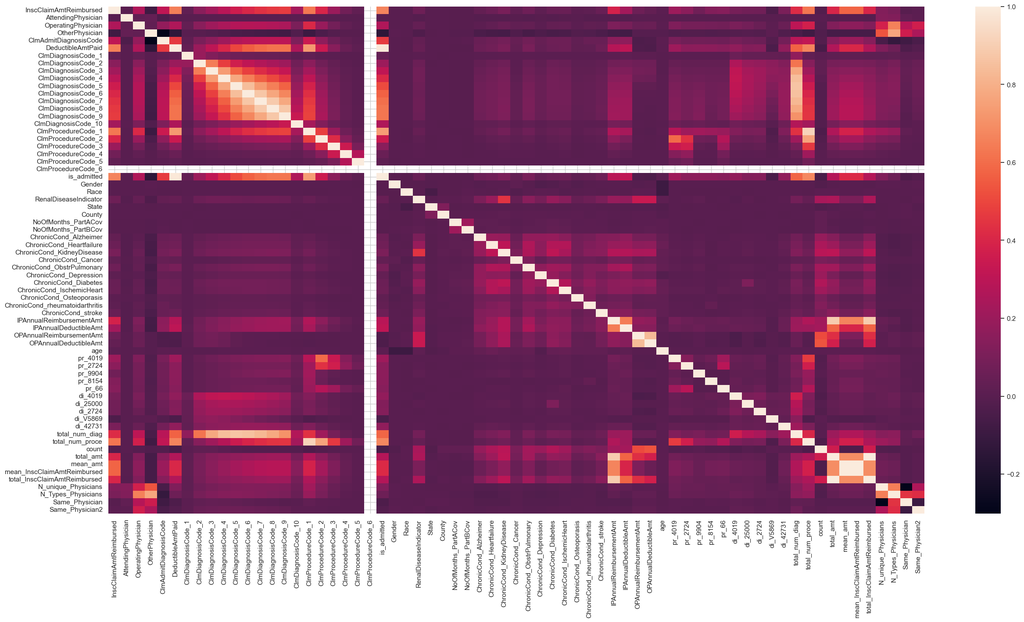

```python
#plot correlation heat map between features
sns.set(context='notebook', style='whitegrid')
plt.figure(figsize=(30, 15))
corr = data_final.corr( numeric_only=True)
sns.heatmap(corr, annot=False)
```

```python
#replace NaN val with 0
#data_final.DiagnosisGroupCode
data_final['DiagnosisGroupCode']= data_final['DiagnosisGroupCode'].replace({np.nan:0})
```

```python
#final check to see if a col val is NaN
col_inf_df=pd.DataFrame()
val = data_final.isnull().sum()
col_inf_df['null_col_count']  = val
col_inf_df['column'] = val.index
col_inf_df.loc[col_inf_df['null_col_count'] !=0]
```

|  | null_col_count | column |
| --- | --- | --- |
| Physician_Team | 467602 | Physician_Team |

```python
col_inf_df.null_col_count.value_counts()
```

```
null_col_count
0         77
467602     1
Name: count, dtype: int64
```

```python
for col in data_final.columns:
    print(col)
```

```
BeneID
ClaimID
ClaimStartDt
ClaimEndDt
Provider
InscClaimAmtReimbursed
AttendingPhysician
OperatingPhysician
OtherPhysician
ClmAdmitDiagnosisCode
DeductibleAmtPaid
DiagnosisGroupCode
ClmDiagnosisCode_1
ClmDiagnosisCode_2
ClmDiagnosisCode_3
ClmDiagnosisCode_4
ClmDiagnosisCode_5
ClmDiagnosisCode_6
ClmDiagnosisCode_7
ClmDiagnosisCode_8
ClmDiagnosisCode_9
ClmDiagnosisCode_10
ClmProcedureCode_1
ClmProcedureCode_2
ClmProcedureCode_3
ClmProcedureCode_4
ClmProcedureCode_5
ClmProcedureCode_6
is_admitted
Physician_Team
Gender
Race
RenalDiseaseIndicator
State
County
NoOfMonths_PartACov
NoOfMonths_PartBCov
ChronicCond_Alzheimer
ChronicCond_Heartfailure
ChronicCond_KidneyDisease
```

[output cut: 23 more lines]

```
di_25000
di_2724
di_V5869
di_42731
total_num_diag
total_num_proce
count
total_amt
mean_amt
mean_InscClaimAmtReimbursed
total_InscClaimAmtReimbursed
N_unique_Physicians
N_Types_Physicians
Same_Physician
Same_Physician2
```

```python
#saving dataframe to csv file to avoid rework
data_final.to_csv("data_final.csv",index= False)
```

```python
data_final = pd.read_csv("data_final.csv")

print(data_final.shape)
data_final.head(5)
```

```
(558211, 78)
```

|  | BeneID | ClaimID | ClaimStartDt | ClaimEndDt | Provider | InscClaimAmtReimbursed | AttendingPhysician | OperatingPhysician | OtherPhysician | ClmAdmitDiagnosisCode | ... | total_num_proce | count | total_amt | mean_amt | mean_InscClaimAmtReimbursed | total_InscClaimAmtReimbursed | N_unique_Physicians | N_Types_Physicians | Same_Physician | Same_Physician2 |
| --- | --- | --- | --- | --- | --- | --- | --- | --- | --- | --- | --- | --- | --- | --- | --- | --- | --- | --- | --- | --- | --- |
| 0 | BENE100000 | CLM126832 | 2009-01-08 | 2009-01-08 | PRV57172 | 50 | 1 | 0 | 0 | 0.0 | ... | 0.0 | 2 | 120 | 60.0 | 60.0 | 120.0 | 1 | 1 | 0 | 0 |
| 1 | BENE100000 | CLM351838 | 2009-05-10 | 2009-05-10 | PRV57172 | 70 | 1 | 0 | 1 | 0.0 | ... | 0.0 | 2 | 120 | 60.0 | 60.0 | 120.0 | 2 | 2 | 0 | 0 |
| 2 | BENE100001 | CLM626521 | 2009-10-12 | 2009-10-12 | PRV52145 | 10 | 1 | 0 | 1 | 1.0 | ... | 0.0 | 10 | 1430 | 143.0 | 143.0 | 1430.0 | 2 | 2 | 0 | 0 |
| 3 | BENE100001 | CLM633318 | 2009-10-16 | 2009-10-16 | PRV54683 | 100 | 1 | 0 | 0 | 1.0 | ... | 0.0 | 10 | 1430 | 143.0 | 143.0 | 1430.0 | 1 | 1 | 0 | 0 |
| 4 | BENE100001 | CLM332544 | 2009-04-30 | 2009-05-02 | PRV54890 | 90 | 1 | 1 | 1 | 1.0 | ... | 0.0 | 10 | 1430 | 143.0 | 143.0 | 1430.0 | 2 | 3 | 0 | 1 |

5 rows × 78 columns

```python
# Now we will drop the columns that are not useful for building machine learning models to predict fraudulent providers.
# We will keep only the relevant features that we have engineered and the target variable in our final dataset.

col_to_remove = ['Provider','BeneID', 'ClaimID', 'ClaimStartDt','ClaimEndDt','AttendingPhysician',\
                 'OperatingPhysician', 'OtherPhysician','ClmAdmitDiagnosisCode','NoOfMonths_PartACov',\
                 'NoOfMonths_PartBCov','DiagnosisGroupCode','PotentialFraud']

data_final.drop(columns=col_to_remove, axis=1, inplace=True)
data_final['target']=data_final['target'].astype(int)
```

```python
data_final.head()
```

|  | InscClaimAmtReimbursed | DeductibleAmtPaid | ClmDiagnosisCode_1 | ClmDiagnosisCode_2 | ClmDiagnosisCode_3 | ClmDiagnosisCode_4 | ClmDiagnosisCode_5 | ClmDiagnosisCode_6 | ClmDiagnosisCode_7 | ClmDiagnosisCode_8 | ... | total_num_proce | count | total_amt | mean_amt | mean_InscClaimAmtReimbursed | total_InscClaimAmtReimbursed | N_unique_Physicians | N_Types_Physicians | Same_Physician | Same_Physician2 |
| --- | --- | --- | --- | --- | --- | --- | --- | --- | --- | --- | --- | --- | --- | --- | --- | --- | --- | --- | --- | --- | --- |
| 0 | 50 | 0.0 | 1.0 | 0.0 | 0.0 | 0.0 | 0.0 | 0.0 | 0.0 | 0.0 | ... | 0.0 | 2 | 120 | 60.0 | 60.0 | 120.0 | 1 | 1 | 0 | 0 |
| 1 | 70 | 0.0 | 1.0 | 0.0 | 0.0 | 0.0 | 0.0 | 0.0 | 0.0 | 0.0 | ... | 0.0 | 2 | 120 | 60.0 | 60.0 | 120.0 | 2 | 2 | 0 | 0 |
| 2 | 10 | 0.0 | 1.0 | 1.0 | 0.0 | 0.0 | 0.0 | 0.0 | 0.0 | 0.0 | ... | 0.0 | 10 | 1430 | 143.0 | 143.0 | 1430.0 | 2 | 2 | 0 | 0 |
| 3 | 100 | 0.0 | 1.0 | 1.0 | 1.0 | 0.0 | 0.0 | 0.0 | 0.0 | 0.0 | ... | 0.0 | 10 | 1430 | 143.0 | 143.0 | 1430.0 | 1 | 1 | 0 | 0 |
| 4 | 90 | 0.0 | 1.0 | 1.0 | 1.0 | 1.0 | 1.0 | 1.0 | 1.0 | 1.0 | ... | 0.0 | 10 | 1430 | 143.0 | 143.0 | 1430.0 | 2 | 3 | 0 | 1 |

5 rows × 65 columns

# Conclusion

To start with we performed some EDA tasks which were remaining from the Milestone 1

We performed the data cleaning and preprocessing.